# NZ GREEN Grid Household Electricity Demand Data

EECA Data Analysis (Part B) Report v1.0

Dortans, C., Anderson, B. and Jack, M.

Last run at: 2019-10-17 15:41:26 (Pacific/Auckland)

# 1 About

## 1.1 Citation

If you wish to use any of the material from this report please cite as:

- Dortans, C., Anderson, B. and Jack, M. (2019) *NZ GREEN Grid Household Electricity Demand Data: EECA Data Analysis (Part B) Report v1.0*, [Centre for Sustainability](http://www.otago.ac.nz/centre-sustainability/), University of Otago: Dunedin.

This work is (c) 2019 the authors. Usage right are specified in the License section (1.3).

## 1.2 Report circulation:

- Public – this report is intended for publication following EECA approval.

## 1.3 License

This work is made available under the Creative Commons [Attribution-ShareAlike 4.0 International (CC BY-SA 4.0) License](https://creativecommons.org/licenses/by-sa/4.0/).

This means you are free to:

- *Share* — copy and redistribute the material in any medium or format
- *Adapt* — remix, transform, and build upon the material for any purpose, even commercially.

Under the following terms:

- *Attribution* — You must give appropriate credit, provide a link to the license, and indicate if changes were made. You may do so in any reasonable manner, but not in any way that suggests the licensor endorses you or your use.
- *ShareAlike* — If you remix, transform, or build upon the material, you must distribute your contributions under the same license as the original.
- *No additional restrictions* — You may not apply legal terms or technological measures that legally restrict others from doing anything the license permits.

**Notices:**

- You do not have to comply with the license for elements of the material in the public domain or where your use is permitted by an applicable exception or limitation.
- No warranties are given. The license may not give you all of the permissions necessary for your intended use. For example, other rights such as publicity, privacy, or moral rights may limit how you use the material.

For the avoidance of doubt and explanation of terms please refer to the full [license notice](https://creativecommons.org/licenses/by-sa/4.0/) and [legal code](https://creativecommons.org/licenses/by-sa/4.0/legalcode).

## 1.4 History

You may not be reading the most recent version of this report. Please check:

- the github [R code repository](https://cfsotago.github.io/GREENGridEECA/);
- our [issues list](https://github.com/CfSOtago/GREENGridEECA/issues) for any unfixed problems;
- our [project documentation site](https://cfsotago.github.io/GREENGridEECA/) and specifically;
- this [report’s edit history](https://github.com/CfSOtago/GREENGridEECA/commits/master/reports/partB_dataAnalysis)

## 1.5 Support

This work was supported by:

- The New Zealand Energy Efficiency and Conservation Authority ([EECA](https://www.eeca.govt.nz/))

# 2 Introduction

This report uses the GREEN Grid project (Stephenson et al. 2017) research data to analyse a variety of residential household appliances and their contribution to peak demand under several scenarios.

# 3 Data

The [NZ GREEN Grid household electricity demand study](https://cfsotago.github.io/GREENGridData/) recruited a sample of c 40 households in each of two regions of New Zealand (Stephenson et al. 2017). The first sample was recruited in early 2014 and the second in early 2015. Research data includes:

- 1 minute electricity power (W) data was collected for each dwelling circuit using [GridSpy](https://gridspy.com/) monitors on each power circuit (and the incoming power). The power values represent mean(W) over the minute preceding the observation timestamp;
- Dwelling & appliance surveys;
- Occupant time-use diaries (focused on energy use).

The data collection was supported by the New Zealand [Ministry of Business, Innovation and Employment (MBIE)](http://www.mbie.govt.nz/) through the [Renewable Energy and the Smart Grid (GREEN Grid)](https://www.otago.ac.nz/centre-sustainability/research/energy/otago050285.html) grant (Contract ID: UOCX1203).

```
## Date in ISO8601 format; converting timezone from UTC to "Pacific/Auckland".
```

# 4 Peak Contribution

In this section we use the GREEN Grid residential sample to estimate the contribution of each appliance to peak demand. For this analysis we use demand data averaged over 30 minute intervals. We consider three different definitions of peak demand:

- Sample winter evenings 17:00 - 21:00. In this case we:
  - find the maximum half-hour demand for each household during the defined peak period
  - calculate the percentage contribution of each separately identifiable load type (lighting, hot water, heat pump, oven) in that half hour.
- Regional/network peak. In this case we:
  - find the 100 maximum regional network (GXP) peak half hours
  - calculate the mean contribution of each identifiable load to mean total load across all households in that region across these 100 half-hours
- Sample co-incident peak. In this case we:
  - find the half-hour across the sample which has the highest total combined demand
  - calculate mean contribution of each identifiable load to mean total load across all households in this half-hour

## 4.1 Winter (June - August) evenings 17:00 – 21:00

### 4.1.1 Average load

In this section we select the peak-period half hours for all households for the winter evening period and then calculate the avergage demand for each dwelling over the period of peak demand.

Table 4.1 shows the winter average demand (W) at ‘peak’ for each dwelling and circuit in 2015. The complete data table across all houses is saved as “Extracted average demand by dwelling and circuit at ‘peak’.csv” and is supplied with the report.

Table 4.1: Example data: Extracted average demand by dwelling and circuit at ‘peak’

| linkID | eecaCircuit | avgPeakDemandW |
| --- | --- | --- |
| rf_01 | Heat Pump or Heating | 2049.789 |
| rf_01 | Hot water | 135.692 |
| rf_01 | Lighting | 213.489 |
| rf_01 | Oven | 70.210 |
| rf_01 | Total | 2812.098 |
| rf_01 | XX_Other | 1496.506 |
| rf_06 | Hot water | 462.728 |
| rf_06 | Lighting | 416.237 |
| rf_06 | Oven | 144.912 |
| rf_06 | Total | 1539.349 |

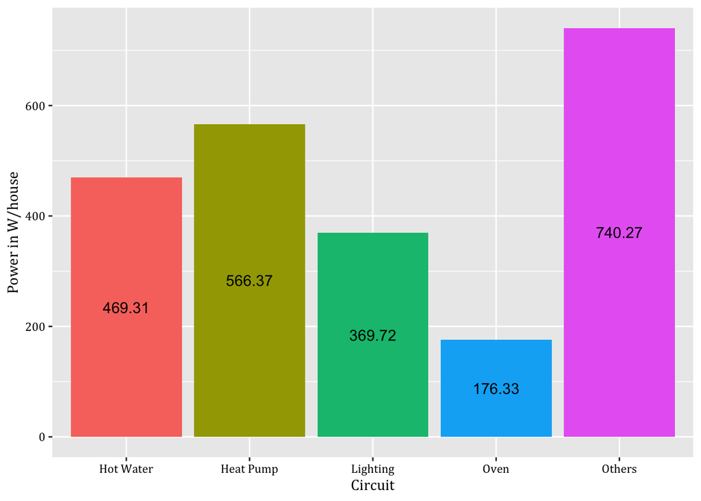

Figure 4.1: Average contribution at ‘peak’ (17:00-21:00) by circuit in winter 2015

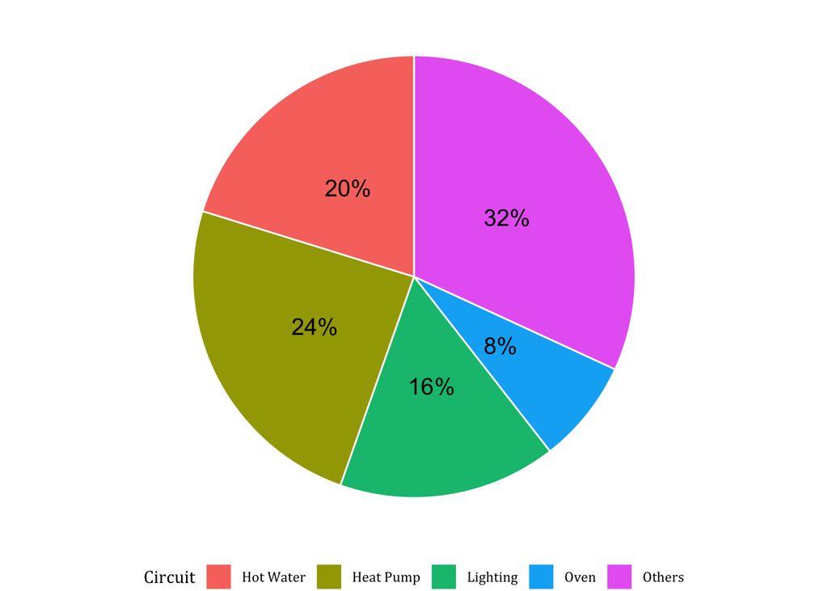

Figure 4.2: Average percentage contribution at ‘peak’ (17:00-21:00) by circuit in winter 2015

We have then used this data to calculate the mean contribution of each identifiable load to peak demand (time period 17:00-21:00) in the sample for winter in 2015. This is shown in Figure 4.1 and Figure 4.2 (as percentage contribution). On average, Heat Pumps contributed the most to peak demand, followed by Hot Water, Lighting, and Oven. Not further specified load contributed 32%.

### 4.1.2 Maximum load

In this section we select the peak-period half hours for all households for the winter evening period and then locate the half-hour which had the maximum total load for that dwelling.

Table 4.2 shows the winter maximum load half-hours for each dwelling and year in winter during the peak periods defined above. In this data extract, NaN indicates that no circuit data was obtained for this dwelling in this specific time period. We also calculate the proportionate contribution of each identifiable load to the total load. The complete data table across all houses is saved as “Extracted winter peak load half-hour circuits.csv” and is supplied with the report.

Table 4.2: Example data: Extracted winter peak load half-hour circuits (NaN indicates no such circuit)

| linkID | year | season | r_dateTime_nz | Heat Pump or Heating | Hot water | Lighting | Oven | Total | XX_Other | contribution_HW | contribution_HP | contribution_LI | contribution_OV | contribution_XX |
| --- | --- | --- | --- | --- | --- | --- | --- | --- | --- | --- | --- | --- | --- | --- |
| rf_01 | 2014 | Winter | 2014-06-20 19:00:00 | 6330.773 | 0.000 | 738.022 | 1296.609 | 10413.442 | 5309.895 | 0.000 | 0.608 | 0.071 | 0.125 | 0.197 |
| rf_01 | 2015 | Winter | 2015-08-09 18:30:00 | 7084.992 | 0.000 | 799.904 | 0.000 | 10145.157 | 6141.460 | 0.000 | 0.698 | 0.079 | 0.000 | 0.223 |
| rf_02 | 2014 | Winter | 2014-07-26 19:30:00 | 453.763 | 445.705 | 253.770 | NaN | 3305.962 | 1142.141 | 0.135 | 0.137 | 0.077 | NaN | NaN |
| rf_06 | 2014 | Winter | 2014-06-23 18:30:00 | NaN | 0.000 | 1209.598 | 3231.005 | 5534.263 | 2027.640 | 0.000 | NaN | 0.219 | 0.584 | NaN |
| rf_06 | 2015 | Winter | 2015-08-25 18:30:00 | NaN | 1971.901 | 1231.017 | 425.517 | 6352.226 | 2274.762 | 0.310 | NaN | 0.194 | 0.067 | NaN |
| rf_06 | 2016 | Winter | 2016-07-23 18:00:00 | NaN | 1967.204 | 926.778 | 1558.859 | 5208.076 | 1233.387 | 0.378 | NaN | 0.178 | 0.299 | NaN |
| rf_06 | 2017 | Winter | 2017-08-13 18:00:00 | NaN | 1963.500 | 632.053 | 1725.007 | 6457.725 | 2152.250 | 0.304 | NaN | 0.098 | 0.267 | NaN |
| rf_06 | 2018 | Winter | 2018-06-06 17:00:00 | NaN | 1920.514 | 345.871 | 1901.049 | 7143.127 | 2644.537 | 0.269 | NaN | 0.048 | 0.266 | NaN |
| rf_07 | 2014 | Winter | 2014-07-16 17:00:00 | NaN | NaN | NaN | 1945.330 | 4428.952 | 920.653 | NaN | NaN | NaN | 0.439 | NaN |
| rf_07 | 2015 | Winter | 2015-06-23 17:00:00 | NaN | NaN | NaN | 1284.661 | 5678.140 | 1235.498 | NaN | NaN | NaN | 0.226 | NaN |

We have then used this data to calculate the mean contribution of each identifiable load to peak demand (time period 17:00-21:00) in the sample and this is shown in Figure 4.3 and Figure 4.4 (as percentage contribution). Figure 4.3 shows the seasonal variation in actual power demand especially for heat pumps and lighting but also shows the relative constancy of hot water. ‘Others’ almost certainly contains some forms of heating as it is much lower in summer. It should be noted that these mean values will mask considerable day to day and inter/intra-household variation On the other hand, and as a consequence the percentage contribution of hot water slightly increases in summer whereas the contribution of heat pumps decreases over summer. Hot water is identified as the appliance that is contributing the most to peak demand in this case.

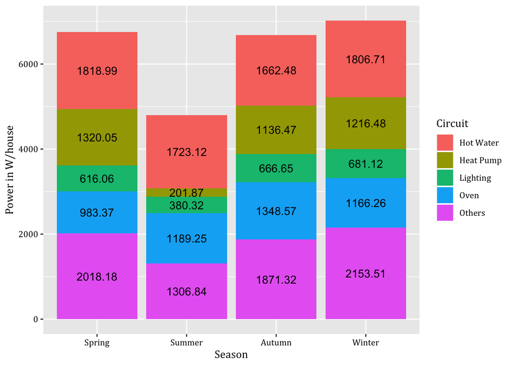

Figure 4.3: Average contribution to daily peak demand (17:00-21:00) per season in 2015

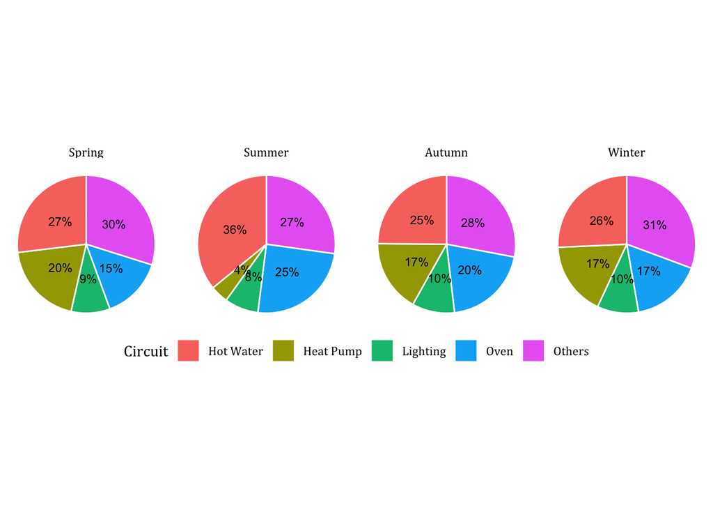

Figure 4.4: Average percentage contribution to peak demand (17:00-21:00) for each season in 2015

## 4.2 Region/network coincident peak

In this section we focus on the contribution of these identifiable loads to regional peak demand. Most of the households in our data set were in the Hawke’s Bay and Taranaki region, so we focus on these regions by separating the sample into the Hawke’s Bay and Taranaki sub-samples.

22 houses are based in Taranaki and 20 houses in Hawke’s Bay. Within the house sample in Taranaki, 31% of the houses have heat pumps installed, 45% hot water cylinders, and 27% other heat sources. In contrast, the Hawke’s Bay sub-sample comprises of 90% heat pumps, 90% hot water cylinder, and 36% other heat sources.

e.g. see https://cfsotago.github.io/GREENGridData/householdAttributeProcessingReport_v1.0.html#51_main_heat_source

To determine the timing of the matching regional peaks, data on regional demand for the Hawke’s Bay and Taranaki Grid Exit Point (GXP) was obtained from the Electricity Authority and for each GXP, the timestamps of the 100 half hours with the highest demand were identified. We then extracted the power demand of each dwelling in each of the two regions during these 100 half hours for analysis.

### 4.2.1 Hawke’s Bay

Table 4.3 presents example data of the extracted peak half-hours by circuit for 2015 for the Hawke’s Bay dwellings. In this example data they are matching to a number of regional peak half hours in June 2015. The complete data table is saved as “Extracted peak load half-hour circuits for Hawke’s Bay.csv” and is supplied with the report.

Table 4.3: Example data: Extracted peak load half-hour circuits for Hawke’s Bay (NaN indicates no such circuit)

| linkID | year | season | r_dateTime_nz | Heat Pump or Heating | Hot water | Lighting | Oven | Total | XX_Other |
| --- | --- | --- | --- | --- | --- | --- | --- | --- | --- |
| rf_29 | 2015 | Winter | 2015-06-05 17:30:00 | NaN | 0.000 | 369.952 | 0 | 3304.606 | 1443.938 |
| rf_29 | 2015 | Winter | 2015-06-08 17:30:00 | NaN | 429.233 | 561.235 | 0 | 3202.406 | 951.441 |
| rf_29 | 2015 | Winter | 2015-06-08 19:00:00 | NaN | 1251.551 | 428.744 | 0 | 3390.361 | 1030.915 |
| rf_29 | 2015 | Winter | 2015-06-15 17:30:00 | NaN | 2547.575 | 548.112 | 0 | 6292.681 | 1642.099 |
| rf_29 | 2015 | Winter | 2015-06-15 18:00:00 | NaN | 1387.409 | 477.960 | 0 | 4983.331 | 1531.111 |
| rf_29 | 2015 | Winter | 2015-06-16 17:30:00 | NaN | 1897.206 | 196.969 | 0 | 3999.964 | 792.159 |
| rf_29 | 2015 | Winter | 2015-06-17 17:30:00 | NaN | 2413.821 | 466.788 | 0 | 5893.419 | 1457.317 |
| rf_29 | 2015 | Winter | 2015-06-17 18:30:00 | NaN | 1451.891 | 452.990 | 0 | 5459.778 | 1817.865 |
| rf_29 | 2015 | Winter | 2015-06-17 19:30:00 | NaN | 0.000 | 305.273 | 0 | 3607.029 | 1620.864 |
| rf_29 | 2015 | Winter | 2015-06-22 17:00:00 | NaN | 0.000 | 301.809 | 0 | 2013.767 | 974.997 |

The average contribution of each identifiable load to the Hawke’s Bay regional peak demand (100 half hours with the highest demand at Hawke’s Bay GXP) for the sample is shown in Figure 4.5. Hot Water and Heat Pumps contribute a mean of 682 Watts and 672 Watts respectively but ‘Others’ (which probably includes heating) contributes 792. Heat Pumps and Hot Water contributed almost equally to regional network peak demand in Hawke’s Bay (27% and 28%), followed by Lighting (10%) and Oven (3%). However, ‘Other’ demand that was not further specified contributed 32%. This is presented in Figure 4.6. it should be noted that the inherent bias in the sample, and the very small sample size in each region means that these % results are almost certainly not robust.

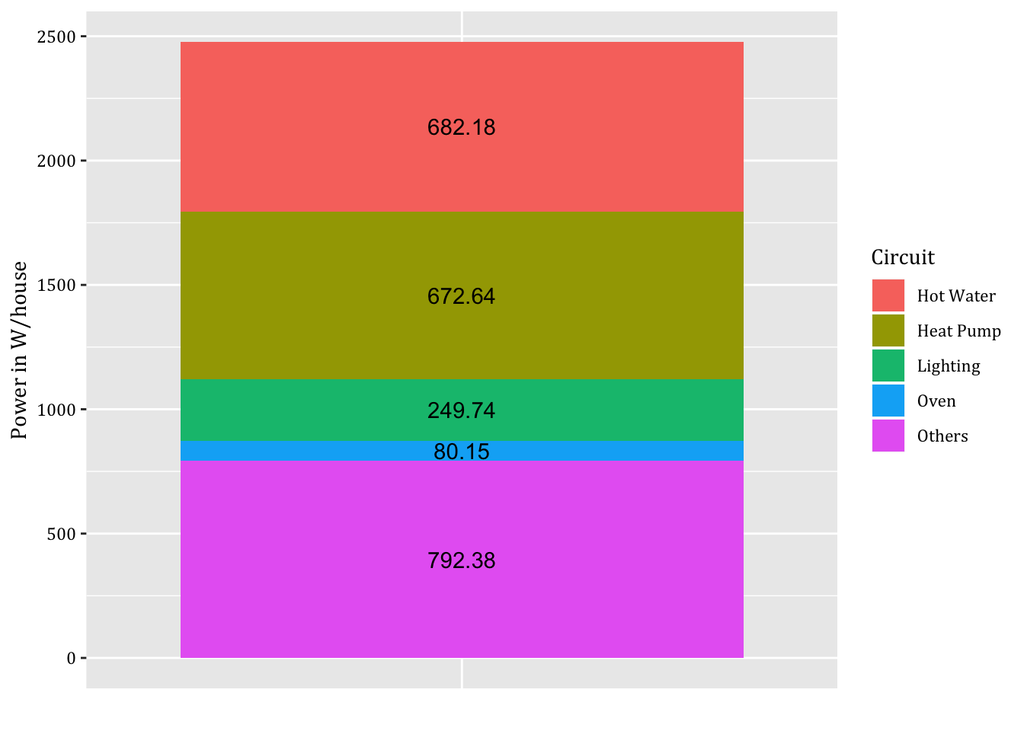

Figure 4.5: Average contribution of each identifiable load in the sample to the Hawke’s bay regional peak (100 half hours with the highest demand at Hawkes Bay GXP) for 2015

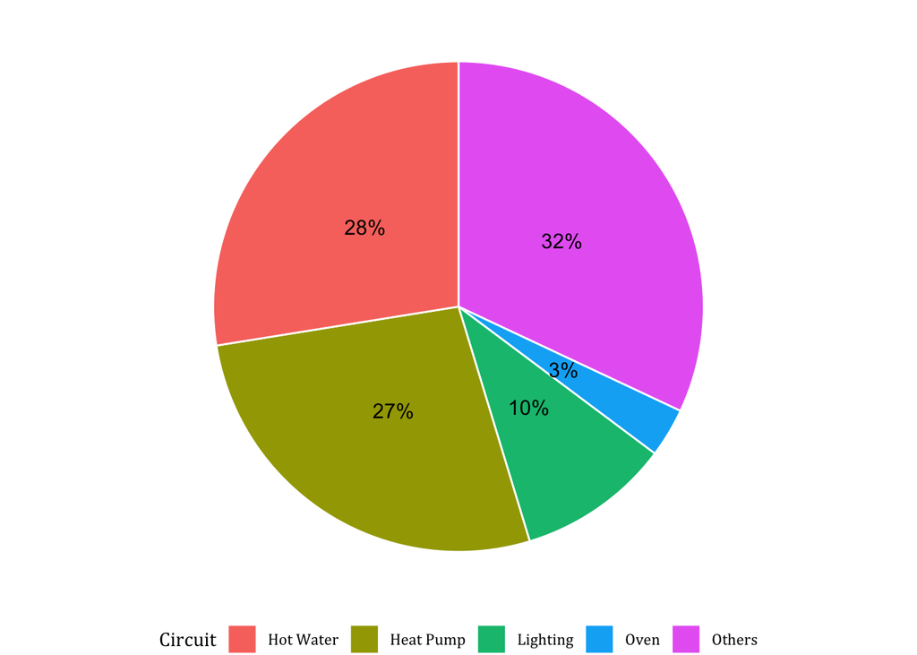

Figure 4.6: Percentage contribution to peak demand for top 100 GXP half hours in Hawkes Bay for 2015

### 4.2.2 Taranaki

Table 4.4 presents example data of the extracted peak half-hours by circuit for 2015 for the Taranaki houses. The complete data table is saved as “Extracted peak load half-hour circuits for Taranaki.csv” and is supplied with the report.

Table 4.4: Example data: Extracted peak load half-hour circuits (NaN indicates no such circuit)

| linkID | year | season | r_dateTime_nz | Heat Pump or Heating | Hot water | Lighting | Oven | Total | XX_Other |
| --- | --- | --- | --- | --- | --- | --- | --- | --- | --- |
| rf_06 | 2015 | Winter | 2015-06-03 17:30:00 | NaN | 1952.753 | 960.153 | 100.335 | 3545.780 | 614.633 |
| rf_06 | 2015 | Winter | 2015-06-03 18:00:00 | NaN | 1924.644 | 868.021 | 2461.480 | 5978.355 | 1470.061 |
| rf_06 | 2015 | Winter | 2015-06-22 17:30:00 | NaN | 0.000 | 0.000 | 0.000 | 179.428 | 88.995 |
| rf_06 | 2015 | Winter | 2015-06-22 18:00:00 | NaN | 0.000 | 143.611 | 0.000 | 509.750 | 210.563 |
| rf_06 | 2015 | Winter | 2015-06-22 18:30:00 | NaN | 0.000 | 16.334 | 0.000 | 202.736 | 92.911 |
| rf_06 | 2015 | Winter | 2015-06-23 17:30:00 | NaN | 0.000 | 139.790 | 1347.506 | 2057.464 | 767.561 |
| rf_06 | 2015 | Winter | 2015-06-23 18:00:00 | NaN | 0.000 | 402.713 | 0.000 | 791.994 | 343.270 |
| rf_06 | 2015 | Winter | 2015-06-23 18:30:00 | NaN | 1497.173 | 421.617 | 0.000 | 2396.132 | 413.044 |
| rf_06 | 2015 | Winter | 2015-06-24 17:30:00 | NaN | 128.629 | 277.768 | 492.224 | 1415.402 | 506.696 |
| rf_06 | 2015 | Winter | 2015-06-24 18:00:00 | NaN | 1412.652 | 400.704 | 470.139 | 2804.887 | 545.708 |

The averaged wattage contribution by circuit is presented in Figure 4.7.Figure 4.8 shows the percentage contribution to peak demand as an average over the date times in the GXP data by circuits. Lighting contributes the most to peak demand with 25%, followed by Heat Pumps (23%), Hot Water (14%), and Oven (8%). Not further specified loads contribute 30% to peak demand in Taranaki.

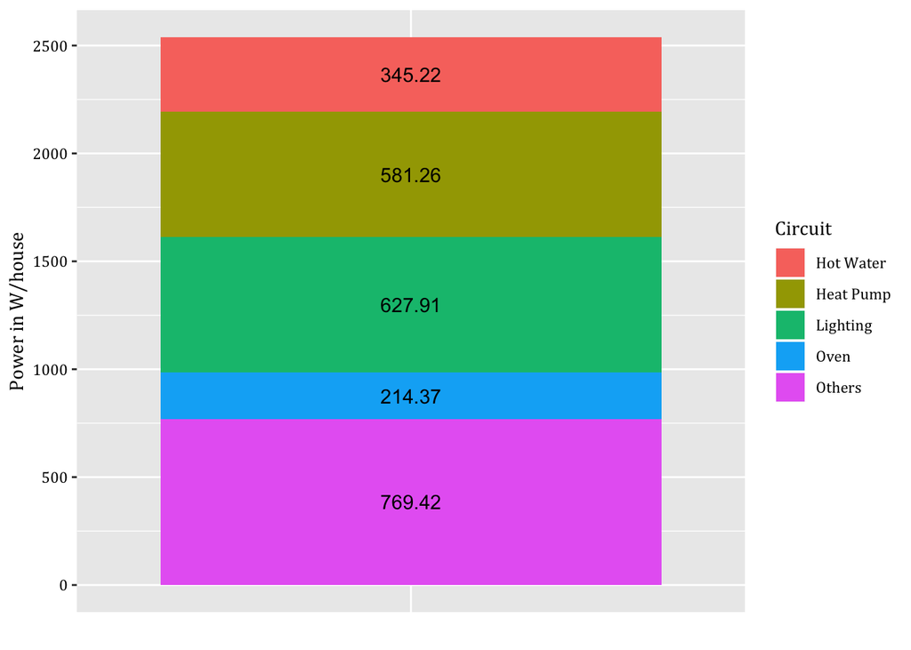

Figure 4.7: Average contribution of each identifiable load to peak demand in Taranaki in 2015

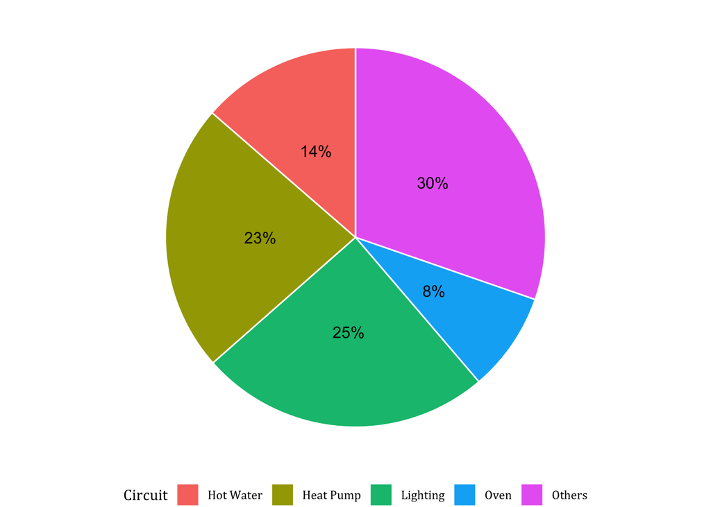

Figure 4.8: Percentage contribution to peak demand for top 100 GXP half hours in Taranaki for 2015

## 4.3 Sample coincident peak

In this section the sum of half-hourly demand over all dwellings in the the GREENGrid sample is used to define peak demand. We define the peak as the 20 half hours with the highest total half-hourly demand summed across all dwellings, which we refer to as the sample coincident peak. This is in contrast to section 4.1 where peak demand was predefined as the time between 17:00 and 21:00 in winter and section 4.2 where peak demand was predefined as the 100 half hours with the largest demand based on regional GXP data.

Table 4.5: Example data: Extracted winter peak load half-hours in descending order for 2015

| eecaCircuit | date | season | year | obsHalfHour | sumOfmeanPowerW | nDwellings | averagePowerW |
| --- | --- | --- | --- | --- | --- | --- | --- |
| Total | 2015-06-28 | Winter | 2015 | 18:00:00 | 104001.93 | 32 | 3250.060 |
| Total | 2015-08-21 | Winter | 2015 | 07:00:00 | 98248.54 | 31 | 3169.308 |
| Total | 2015-06-23 | Winter | 2015 | 18:00:00 | 104026.60 | 33 | 3152.321 |
| Total | 2015-06-24 | Winter | 2015 | 07:00:00 | 103284.24 | 33 | 3129.825 |
| Total | 2015-05-29 | Autumn | 2015 | 07:00:00 | 104143.56 | 35 | 2975.530 |
| Total | 2015-06-17 | Winter | 2015 | 07:00:00 | 97474.05 | 33 | 2953.759 |
| Total | 2015-08-12 | Winter | 2015 | 07:00:00 | 91424.73 | 31 | 2949.185 |
| Total | 2015-06-23 | Winter | 2015 | 17:30:00 | 97292.94 | 33 | 2948.271 |
| Total | 2015-06-26 | Winter | 2015 | 07:00:00 | 97153.23 | 33 | 2944.037 |
| Total | 2015-06-25 | Winter | 2015 | 07:30:00 | 96818.35 | 33 | 2933.889 |

Again, these results should be viewed with some caution due to the non-representative nature of the GREEN Grid sample. While they represent the sample co-incident peak contributions, we cannot assume that this is representative of all New Zealand dwellings.

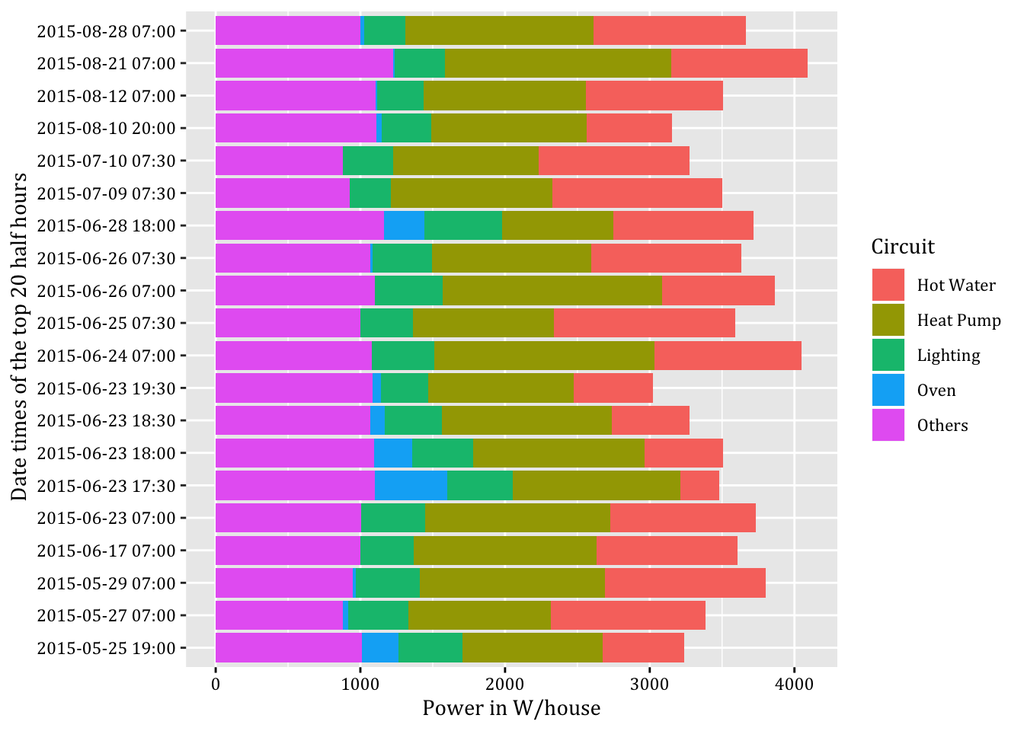

Figure 4.9: Average appliance contribution to peak demand for the top 20 half hours in the sample)

# 5 Annual Contribution

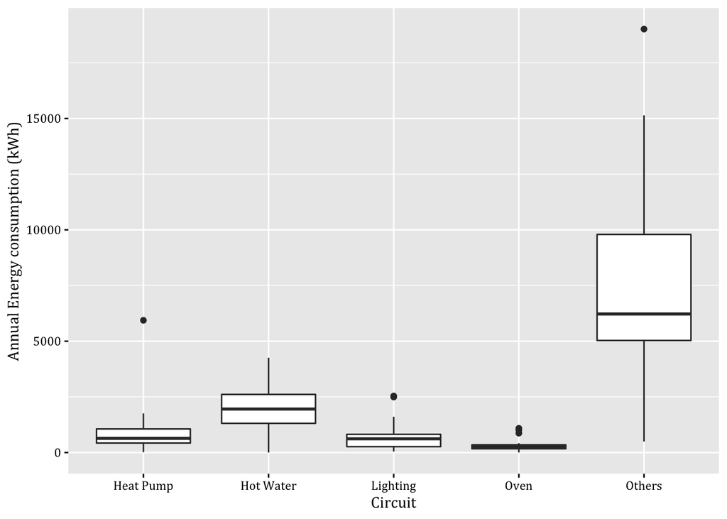

Figure 5.1: Box and whisker plot of annual energy consumption (per house) of each identifiable load for 2015

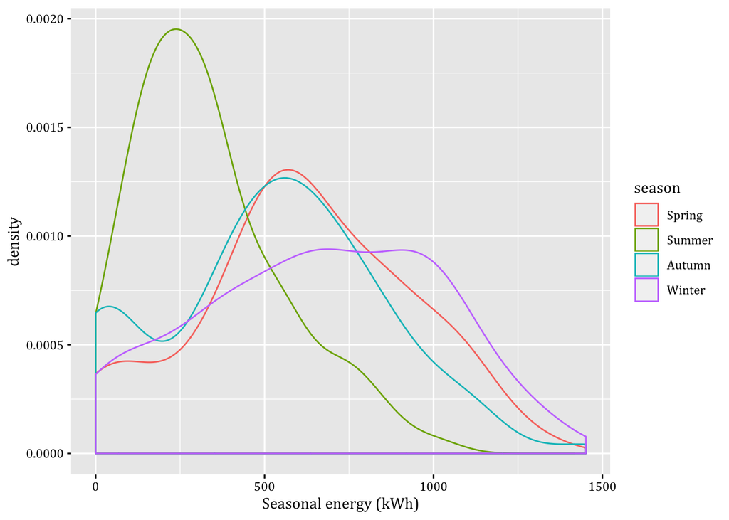

Figure 5.2: Distribution of seasonal energy consumption for Hot Water for all houses for 2015

In contrast, Figure 5.3 presents the seasonal energy consumption for Heat Pumps and considers each dwelling and season. As expected, most energy consumption is in winter. In summer, total energy consumption is mostly 0 (appliance is turned off). Only a few observatons registered energy consumption in summer (cooling?).

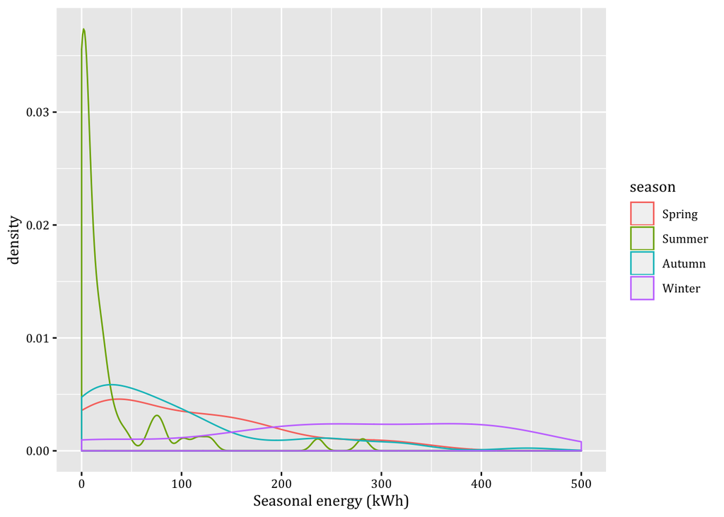

Figure 5.3: Distribution of seasonal energy consumption for Heat Pumps for all houses for 2015

Energy consumption of Lighting is particularly apparent in spring, autumn, and winter as presented in Figure 5.4. Less energy consumption is identified in summer.

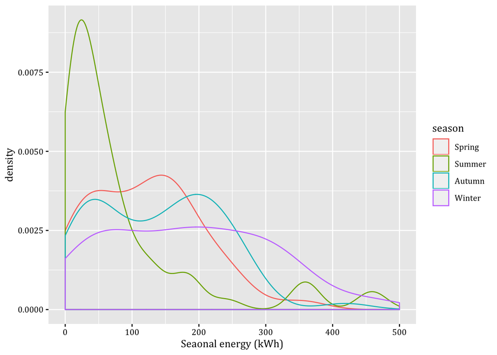

Figure 5.4: Distribition of seasonal energy consumption for Lighting for all houses for 2015

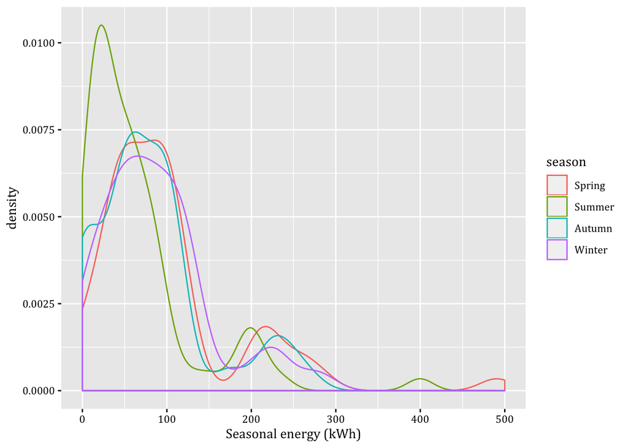

Figure 5.5: Distribution of seasonal energy consumption for Ovens for all houses for 2015

For “Others”, there is a lot of seasonal variation in seasonal energy consumption as shown in Figure 5.6. As this circuit contains appliances not further specified it is difficult to identify the appliance causing this energy consumption, particularly in summer. Therefore, further research is necessary.

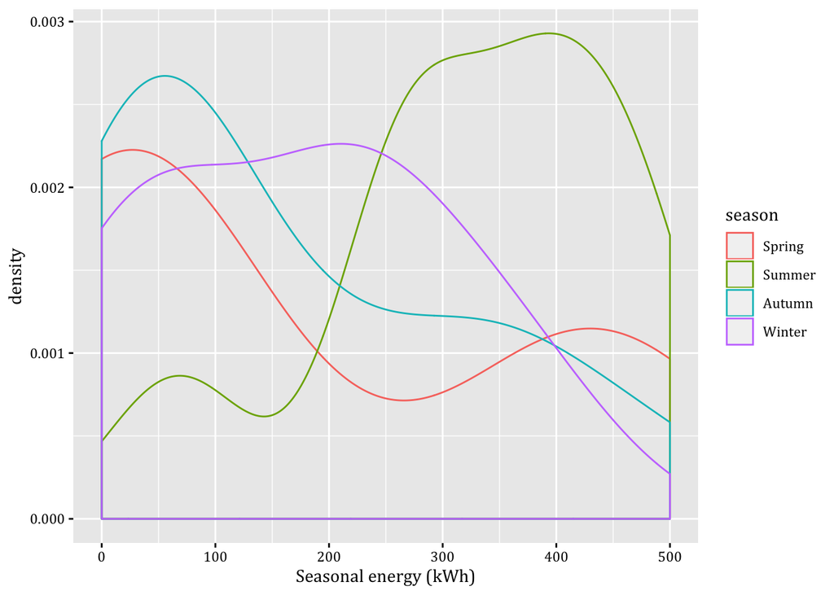

Figure 5.6: Distribution of seasonal energy consumption for Others for all houses for 2015

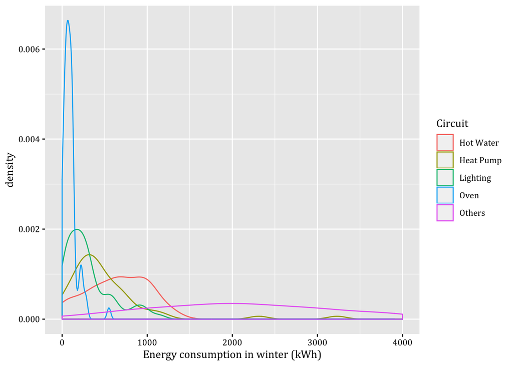

Furthermore, Figure 5.7 shows the variation in circuits for winter 2015. On average, Hot Water used the most energy, followed by Heat Pumps, Lighting, and Ovens. Not further specifies load is indicated as ‘Others’.

# 6 Load Factor

Table 6.1: Example data: Extracted load factor by household and circuit

| linkID | eecaCircuit | avgPeakDemandW | avgDemandW | LoadFactor |
| --- | --- | --- | --- | --- |
| rf_01 | Heat Pump or Heating | 2049.789 | 845.685 | 0.413 |
| rf_01 | Hot water | 135.692 | 185.337 | 1.366 |
| rf_01 | Lighting | 213.489 | 108.664 | 0.509 |
| rf_01 | Oven | 70.210 | 35.619 | 0.507 |
| rf_01 | Total | 2812.098 | 1471.622 | 0.523 |
| rf_01 | XX_Other | 1496.506 | 828.730 | 0.554 |
| rf_02 | Heat Pump or Heating | NA | 201.023 | NA |
| rf_02 | Hot water | NA | 346.996 | NA |
| rf_02 | Lighting | NA | 31.375 | NA |
| rf_02 | Total | NA | 1008.554 | NA |

The Load Factor (LF) is defined as the ratio of average demand (W) across all half hours to peak demand (W). The LF provides a measure of how much the load contributes to peak. If the LF for a particular load is 1 then the load is flat. Values greater 1 indicate that the average demand outside the peak period is higher than the average demand inside it. A LF less than 1 shows that the load disproportionately contributes to the peak. In this section we define peak demand to be the average demand between 17:00-21:00 in winter. Table 6.1 shows the first rows of our calculation.

The full data table containing LFs (if available) for each house is saved as “Extracted load factor by household and circuit.csv” and supplied with the report.

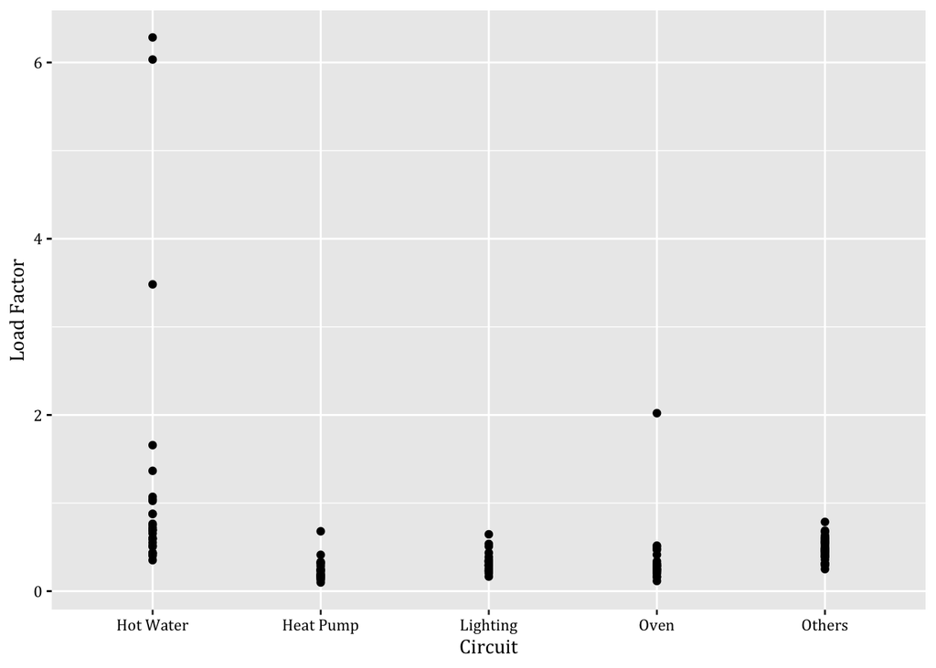

Figure 6.1: Load Factor distribution by circuit for peak demand (17:00-21:00) in winter 2015

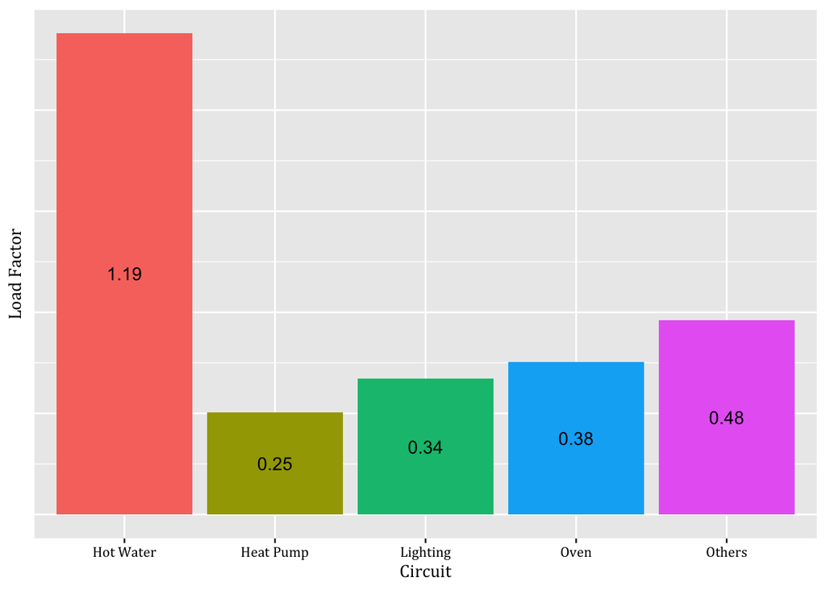

Figure 6.2: Load Factor by circuit for peak demand (17:00-21:00) in winter 2015

# 7 Summary

# 8 Data Annex

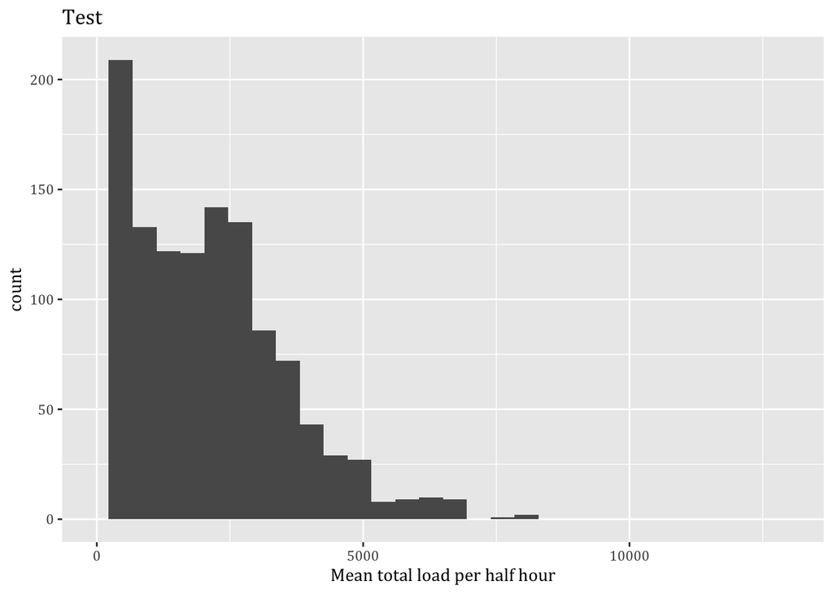

Figure 8.1: test mean total load

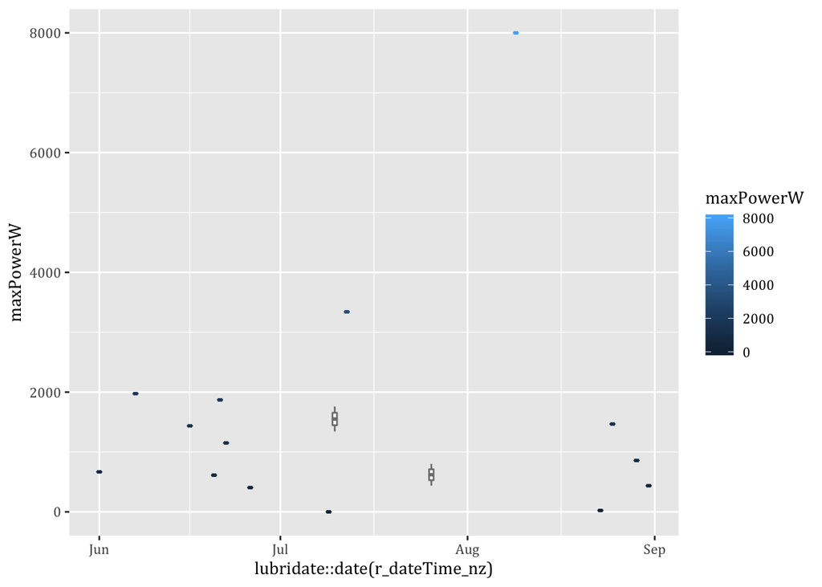

Figure 8.2: Test max power for heating

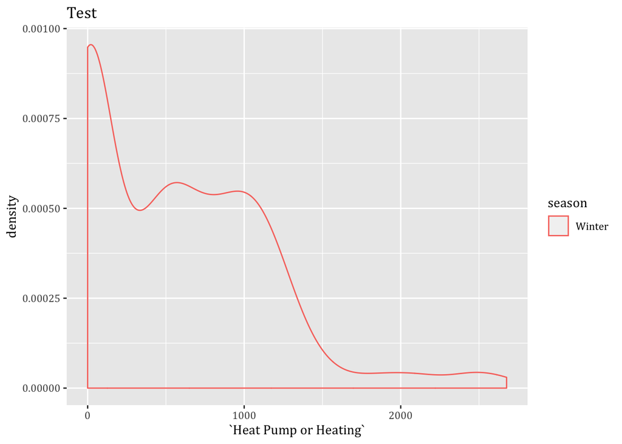

Figure 8.3: Test mean power for heating in peak half load hours

[figure not shown]

## 8.1 Categorised circuit labels

Table 8.1 shows the categorised circuit labels used in the analysis.

|  | Heat Pump or Heating | Hot water | Lighting | Oven | Total | XX_Other |
| --- | --- | --- | --- | --- | --- | --- |
| Bed 2, 2nd Fridge | 0 | 0 | 0 | 0 | 0 | 9 |
| Bedroom & Lounge Heat Pumps | 0 | 0 | 0 | 0 | 0 | 18 |
| Bedrooms & Lounge | 0 | 0 | 0 | 0 | 0 | 17 |
| Cooking Bath tile heat | 0 | 0 | 0 | 0 | 0 | 6 |
| Downstairs (inc 1 Heat Pump) | 0 | 0 | 0 | 0 | 0 | 18 |
| Fridge | 0 | 0 | 0 | 0 | 0 | 16 |
| Hallway & Washing Machine | 0 | 0 | 0 | 0 | 0 | 5 |
| Heat Pump | 173 | 0 | 0 | 0 | 0 | 0 |
| Heat Pump (x2) & Lounge Power | 0 | 0 | 0 | 0 | 0 | 3 |
| Heat Pump & 2 x Bathroom Heat | 0 | 0 | 0 | 0 | 0 | 6 |
| Heat Pump & Bedroom 2 | 0 | 0 | 0 | 0 | 0 | 6 |
| Heat Pump & Kitchen Appliances | 0 | 0 | 0 | 0 | 0 | 15 |
| Heat Pump & Lounge | 0 | 0 | 0 | 0 | 0 | 18 |
| Heat Pump & Misc | 0 | 0 | 0 | 0 | 0 | 7 |
| Heat Pump & Washing Machine | 0 | 0 | 0 | 0 | 0 | 10 |
| Heating | 14 | 0 | 0 | 0 | 0 | 0 |
| Hob | 0 | 0 | 0 | 0 | 0 | 30 |
| Hot water | 0 | 8 | 0 | 0 | 0 | 0 |
| Hot Water | 0 | 11 | 0 | 0 | 0 | 0 |
| Hot Water (2 elements) | 0 | 14 | 0 | 0 | 0 | 0 |
| Hot Water - Controlled | 0 | 232 | 0 | 0 | 0 | 0 |
| Hot Water - Controlled (HEMS) | 0 | 19 | 0 | 0 | 0 | 0 |
| Hot Water - Uncontrolled | 0 | 39 | 0 | 0 | 0 | 0 |
| Hot Water Cpbd Heater- Cont | 0 | 18 | 0 | 0 | 0 | 0 |
| imputedTotalDemand_circuitsToSum_v1.1 | 0 | 0 | 0 | 0 | 446 | 0 |
| Incomer - All | 0 | 0 | 0 | 0 | 0 | 108 |
| Incomer - Uncontrolled | 0 | 0 | 0 | 0 | 0 | 218 |
| Incomer -Uncontrolled | 0 | 0 | 0 | 0 | 0 | 15 |
| Incomer 1 | 0 | 0 | 0 | 0 | 0 | 5 |
| Incomer 1 - All | 0 | 0 | 0 | 0 | 0 | 18 |

[output cut: 77 more lines]

## 8.2 Original data description

Descriptive statistics for aggregate half hourly power data for all households and all circuits:

```
## Skim summary statistics
##  n obs: 13075606
##  n variables: 8
##
## ── Variable type:character ────────────────────────────
##            variable missing complete        n min max empty n_unique
##             circuit       0 13075606 13075606   7  37     0      298
##              linkID       0 13075606 13075606   5   6     0       45
##  r_dateTimeHalfHour       0 13075606 13075606  20  20     0    77345
##
## ── Variable type:integer ──────────────────────────────
##  variable missing complete        n  mean   sd p0 p25 p50 p75 p100
##      nObs       0 13075606 13075606 30.01 1.21  1  30  30  30   64
##      hist
##  ▁▁▁▇▁▁▁▁
##
## ── Variable type:numeric ──────────────────────────────
##    variable missing complete        n   mean      sd        p0 p25    p50
##   maxPowerW       0 13075606 13075606 618.38 1162.94  -6970.85   0 140.99
##  meanPowerW       0 13075606 13075606 298.23  711.19  -7627.66   0  76.85
##   minPowerW       0 13075606 13075606 124.16  560.72 -12407.52   0  15.33
##    sdPowerW     705 13074901 13075606 163     322.71      0      0  32.94
##     p75     p100     hist
##  598.49 30822.4  ▁▇▁▁▁▁▁▁
##  329.2  10981.59 ▁▁▁▇▁▁▁▁
##  149.99  9600.58 ▁▁▁▁▇▁▁▁
##  102.45  5627.37 ▇▁▁▁▁▁▁▁
```

The following tables show descriptive statistics for the meanPowerW values for each circuit by household.

Table 8.2: rf_01: Mean of half-hourly mean power (W) by circuit type

| circuit | meanPowerW | minPowerW | maxPowerW | nObs |
| --- | --- | --- | --- | --- |
| Heating$1633 | 960.23691 | 0.000 | 7084.992 | 28401 |
| Hot water$1636 | 216.74744 | 0.000 | 1874.646 | 28401 |
| Kitchen power$1632 | 203.90506 | 0.000 | 3048.565 | 28401 |
| Lights$1635 | 118.29809 | 0.000 | 1102.658 | 28401 |
| Mains$1634 | 1661.72822 | 90.722 | 10981.588 | 28401 |
| Range$1637 | 39.21129 | 0.000 | 3550.979 | 28401 |
| imputedTotalDemand_circuitsToSum_v1.1 | 1662.01730 | 90.722 | 10981.588 | 28401 |
| All | 694.59204 | 0.000 | 10981.588 | 198807 |

Table 8.2: rf_02: Mean of half-hourly mean power (W) by circuit type

| circuit | meanPowerW | minPowerW | maxPowerW | nObs |
| --- | --- | --- | --- | --- |
| Cooking Bath tile heat$1573 | 135.77070 | 0.000 | 798.9143 | 19412 |
| Fridge$1572 | 18.98057 | 0.000 | 126.3063 | 19412 |
| Heating$1576 | 160.75117 | 0.000 | 3360.7323 | 19412 |
| Hot Water$1574 | 234.30121 | 0.000 | 2215.7370 | 19412 |
| Lights$1577 | 23.67056 | 0.000 | 559.3363 | 19412 |
| Mains$1575 | 721.14730 | 25.467 | 7427.8692 | 19412 |
| imputedTotalDemand_circuitsToSum_v1.1 | 721.25805 | 25.467 | 7427.8692 | 19412 |
| All | 287.98280 | 0.000 | 7427.8692 | 135884 |

Table 8.2: rf_06: Mean of half-hourly mean power (W) by circuit type

| circuit | meanPowerW | minPowerW | maxPowerW | nObs |
| --- | --- | --- | --- | --- |
| Hot Water - Controlled$2248 | 413.58656 | 0.00000 | 2055.397 | 62810 |
| Incomer - Uncontrolled$2249 | 528.37421 | -1293.19033 | 5881.824 | 62810 |
| Kitchen$2246 | 101.85379 | 0.00000 | 1723.618 | 62810 |
| Laundry, Downstairs & Lounge$2245 | 237.56314 | 0.00000 | 2799.643 | 62810 |
| Lighting$2244 | 117.43964 | 0.00000 | 2160.544 | 62810 |
| Oven & Hob$2247 | 19.62877 | -24.64467 | 3919.073 | 62810 |
| imputedTotalDemand_circuitsToSum_v1.1 | 942.01325 | -1284.93400 | 7143.127 | 62810 |
| All | 337.20848 | -1293.19033 | 7143.127 | 439670 |

Table 8.2: rf_07: Mean of half-hourly mean power (W) by circuit type

| circuit | meanPowerW | minPowerW | maxPowerW | nObs |
| --- | --- | --- | --- | --- |
| Incomer 1 - Uncontrolled$2726 | 254.97346 | -41.633333 | 2999.776 | 67153 |
| Incomer 2 - Uncontrolled$2725 | 349.55311 | 0.000000 | 5118.139 | 67153 |
| Kitchen Appliances & Laundry$2722 | 201.91405 | -41.100000 | 2440.366 | 67153 |
| Microwave$2721 | 42.54906 | 0.000000 | 1788.205 | 67153 |
| Oven$2724 | 104.30133 | 0.000000 | 3399.987 | 67153 |
| Workshop$2723 | 18.54298 | -7.428571 | 1759.159 | 67153 |
| imputedTotalDemand_circuitsToSum_v1.1 | 604.56831 | 20.433333 | 5912.322 | 67153 |
| All | 225.20033 | -41.633333 | 5912.322 | 470071 |

Table 8.2: rf_08: Mean of half-hourly mean power (W) by circuit type

| circuit | meanPowerW | minPowerW | maxPowerW | nObs |
| --- | --- | --- | --- | --- |
| Heat Pump$2092 | 67.12562 | 0.000 | 2036.822 | 51639 |
| Hot Water - Controlled$2094 | 272.31189 | 0.000 | 2366.140 | 51639 |
| Incomer - Uncontrolled$2093 | 772.53902 | 244.899 | 6425.929 | 51639 |
| Kitchen$2089 | 136.33455 | 0.000 | 2273.916 | 51639 |
| Laundry & 2nd Fridge Freezer$2090 | 146.05024 | 0.000 | 3843.133 | 51639 |
| Oven & Hob$2091 | 48.22041 | 0.000 | 3480.848 | 51639 |
| imputedTotalDemand_circuitsToSum_v1.1 | 1044.94407 | 244.899 | 7882.448 | 51639 |
| All | 355.36083 | 0.000 | 7882.448 | 361473 |

Table 8.2: rf_09: Mean of half-hourly mean power (W) by circuit type

| circuit | meanPowerW | minPowerW | maxPowerW | nObs |
| --- | --- | --- | --- | --- |
| Heat Pump & Bedroom 2$2731 | 153.40526 | -26.87667 | 3242.937 | 17605 |
| Incomer 1 - Uncont - Inc Hob$2729 | 407.19026 | 38.83267 | 3396.080 | 17605 |
| Incomer 2 - Uncont - Inc Oven$2730 | 241.25607 | -26.04000 | 3920.391 | 17605 |
| Kitchen Appliances$2727 | 110.67502 | 24.50100 | 1271.055 | 17605 |
| Laundry$2732 | 16.05779 | 0.00000 | 1479.713 | 17605 |
| Lounge, Dining & Bedrooms$2728 | 169.89889 | 0.00000 | 3062.734 | 17605 |
| imputedTotalDemand_circuitsToSum_v1.1 | 648.58905 | 13.81733 | 5490.639 | 17605 |
| All | 249.58176 | -26.87667 | 5490.639 | 123235 |

Table 8.2: rf_10: Mean of half-hourly mean power (W) by circuit type

| circuit | meanPowerW | minPowerW | maxPowerW | nObs |
| --- | --- | --- | --- | --- |
| Bedrooms & Lounge$2602 | 130.08729 | -358.24333 | 1319.592 | 60754 |
| Heat Pump$2598 | 48.31930 | 0.00000 | 2510.320 | 60754 |
| Incomer - All$2599 | 596.13591 | 89.53033 | 6202.287 | 60754 |
| Kitchen Appliances$2601 | 107.85218 | 0.00000 | 2090.831 | 60754 |
| Laundry & Garage$2597 | 223.85985 | 21.78100 | 3457.719 | 60754 |
| Oven$2600 | 28.88877 | 0.00000 | 2444.982 | 60754 |
| imputedTotalDemand_circuitsToSum_v1.1 | 596.16782 | 89.53033 | 6202.287 | 60754 |
| All | 247.33016 | -358.24333 | 6202.287 | 425278 |

Table 8.2: rf_11: Mean of half-hourly mean power (W) by circuit type

| circuit | meanPowerW | minPowerW | maxPowerW | nObs |
| --- | --- | --- | --- | --- |
| Heat Pump & Lounge$2590 | 221.93527 | 0.0000000 | 3314.134 | 70927 |
| Hob$2589 | 20.28093 | -0.7333333 | 2354.543 | 70927 |
| Hot Water Cpbd Heater- Cont$2586 | 76.91429 | 0.0000000 | 1955.707 | 70927 |
| Incomer - Uncontrolled$2585 | 439.90404 | 22.5333333 | 5982.562 | 70927 |
| Kitchen Appliances & Laundry$2588 | 139.70756 | 0.0000000 | 3144.275 | 70927 |
| Spa - Uncontrolled$2587 | 29.10379 | 0.0000000 | 3044.716 | 70927 |
| imputedTotalDemand_circuitsToSum_v1.1 | 545.94273 | 22.5333333 | 8698.006 | 70927 |
| All | 210.54123 | -0.7333333 | 8698.006 | 496489 |

Table 8.2: rf_12: Mean of half-hourly mean power (W) by circuit type

| circuit | meanPowerW | minPowerW | maxPowerW | nObs |
| --- | --- | --- | --- | --- |
| Incomer 1 - Hot Water - Cont$2626 | 431.69058 | 0.00000 | 3057.669 | 13310 |
| Incomer 2 - Uncontrolled$2625 | 255.26592 | 16.27286 | 4005.747 | 13310 |
| Incomer 3 - Uncontrolled$2627 | 93.38327 | -32.41120 | 1023.548 | 13310 |
| Kitchen Appliances & Lounge$2630 | 147.10153 | -1.68640 | 2063.290 | 13310 |
| Laundry, Fridge & Microwave$2628 | 63.83951 | -26.40826 | 993.040 | 13310 |
| Oven$2629 | 93.47560 | 0.00000 | 3676.903 | 13310 |
| imputedTotalDemand_circuitsToSum_v1.1 | 780.43025 | 48.00048 | 6001.540 | 13310 |
| All | 266.45524 | -32.41120 | 6001.540 | 93170 |

Table 8.2: rf_13: Mean of half-hourly mean power (W) by circuit type

| circuit | meanPowerW | minPowerW | maxPowerW | nObs |
| --- | --- | --- | --- | --- |
| Downstairs (inc 1 Heat Pump)$2212 | 7.250718 | -2343.7876667 | 2967.435 | 72683 |
| Hot Water - Controlled$2208 | 198.864226 | 0.0000000 | 2311.007 | 72683 |
| Incomer - Uncontrolled$2209 | 1455.687777 | 141.7340000 | 9575.828 | 72683 |
| Kitchen & Laundry$2213 | 436.178197 | 76.6173333 | 4445.761 | 72683 |
| Oven & Hob$2210 | 107.570635 | -0.5226667 | 3689.630 | 72683 |
| Upstairs Heat Pumps$2211 | 147.743324 | -46.2900000 | 2762.926 | 72683 |
| imputedTotalDemand_circuitsToSum_v1.1 | 1455.798986 | 141.7340000 | 9575.828 | 72683 |
| All | 544.156266 | -2343.7876667 | 9575.828 | 508781 |

Table 8.2: rf_14: Mean of half-hourly mean power (W) by circuit type

| circuit | meanPowerW | minPowerW | maxPowerW | nObs |
| --- | --- | --- | --- | --- |
| Hot Water - Controlled$2719 | 229.63362 | -525.4233 | 963.0263 | 59477 |
| Incomer 1 - Uncont inc Stove$2718 | 280.63840 | 0.0000 | 4072.8347 | 59477 |
| Incomer 2 - Uncont inc Oven$2717 | 102.71532 | -1372.3987 | 2974.6097 | 59477 |
| Kitchen Appliances$2715 | 75.55101 | -586.9623 | 2694.3280 | 59477 |
| Laundry & Microwave$2720 | 172.13112 | 0.0000 | 3690.1560 | 59477 |
| Power Outlets$2716 | 37.49355 | -944.9340 | 1939.8627 | 59477 |
| imputedTotalDemand_circuitsToSum_v1.1 | 613.05153 | -1120.3857 | 6565.6810 | 59477 |
| All | 215.88779 | -1372.3987 | 6565.6810 | 416339 |

Table 8.2: rf_15b: Mean of half-hourly mean power (W) by circuit type

| circuit | meanPowerW | minPowerW | maxPowerW | nObs |
| --- | --- | --- | --- | --- |
| Hob$3954 | 18.63477 | -134.600000 | 1831.218 | 13040 |
| Hot Water$3952 | 411.24684 | 0.000000 | 1998.152 | 13040 |
| Incomer 1$3956 | 693.70182 | 1.139333 | 5209.020 | 13040 |
| Incomer 2$3955 | 561.38914 | -660.500000 | 5345.709 | 13040 |
| Laundry & Kitchen Appliances$3951 | 259.59320 | -564.166667 | 4637.651 | 13040 |
| Oven$3953 | 31.02041 | 0.000000 | 1648.313 | 13040 |
| imputedTotalDemand_circuitsToSum_v1.1 | 1255.17370 | -586.433333 | 7318.499 | 13040 |
| All | 461.53712 | -660.500000 | 7318.499 | 91280 |

Table 8.2: rf_16: Mean of half-hourly mean power (W) by circuit type

| circuit | meanPowerW | minPowerW | maxPowerW | nObs |
| --- | --- | --- | --- | --- |
| Hallway & Washing Machine$2683 | 108.15574 | -4.552 | 990.3657 | 12416 |
| Hot Water - Controlled$2679 | 299.68561 | 0.000 | 2327.8963 | 12416 |
| Incomer 1 - Uncont inc Oven$2681 | 61.80580 | 0.000 | 2251.0390 | 12416 |
| Incomer 2 - Uncont inc Stove$2680 | 176.84312 | 0.000 | 2164.4770 | 12416 |
| Kitchen Appliances & Bedrooms$2684 | 39.71844 | 0.000 | 2247.6567 | 12416 |
| Microwave & Breadmaker$2682 | 59.20784 | 0.000 | 756.9517 | 12416 |
| imputedTotalDemand_circuitsToSum_v1.1 | 538.38054 | 23.855 | 4486.0077 | 12416 |
| All | 183.39958 | -4.552 | 4486.0077 | 86912 |

Table 8.2: rf_17a: Mean of half-hourly mean power (W) by circuit type

| circuit | meanPowerW | minPowerW | maxPowerW | nObs |
| --- | --- | --- | --- | --- |
| Heat Pump$2148 | 25.98453 | 0.0000000 | 3489.125 | 32019 |
| Hot Water - Controlled$2150 | 88.39686 | -0.0333333 | 2056.734 | 32019 |
| Incomer 1 - Uncont - inc Hob$2152 | 200.58446 | 21.2280000 | 4712.595 | 32019 |
| Incomer 2 - Uncont - inc Oven$2151 | 237.83215 | -376.0673333 | 4797.083 | 32019 |
| Kitchen Appliances$2147 | 98.30310 | -379.2153333 | 1748.831 | 32019 |
| Laundry$2149 | 24.14114 | 0.0000000 | 2147.561 | 32019 |
| imputedTotalDemand_circuitsToSum_v1.1 | 526.84766 | -332.6076667 | 7611.202 | 32019 |
| All | 171.72713 | -379.2153333 | 7611.202 | 224133 |

Table 8.2: rf_17b: Mean of half-hourly mean power (W) by circuit type

| circuit | meanPowerW | minPowerW | maxPowerW | nObs |
| --- | --- | --- | --- | --- |
| Incomer 1 - inc Top Oven$5620 | 137.456088 | 0.00000 | 2831.7230 | 9153 |
| Incomer 2 - inc Bottom Oven$5621 | 216.215229 | 36.21833 | 2333.4967 | 9153 |
| Kitchen Appliances$5625 | 22.879507 | 0.00000 | 622.9377 | 9153 |
| Laundry & Garage$5624 | 85.968666 | 0.00000 | 2039.3000 | 9153 |
| Lighting 1/2$5623 | -1.721405 | -68.60867 | 14.6000 | 9153 |
| Lighting 2/2$5622 | 7.883909 | 0.00000 | 166.4357 | 9153 |
| imputedTotalDemand_circuitsToSum_v1.1 | 353.671318 | 42.60500 | 3819.8710 | 9153 |
| All | 117.479045 | -68.60867 | 3819.8710 | 64071 |

Table 8.2: rf_18: Mean of half-hourly mean power (W) by circuit type

| circuit | meanPowerW | minPowerW | maxPowerW | nObs |
| --- | --- | --- | --- | --- |
| Hot Water - Controlled$2129 | 348.40618 | -74.2000 | 2107.445 | 18032 |
| Incomer 1 - Uncontrolled$2128 | 237.97939 | 0.0000 | 3485.951 | 18032 |
| Incomer 2 - Uncontrolled$2130 | 857.55685 | -890.5782 | 6400.352 | 18032 |
| Kitchen Appliances & Ventilati$2131 | 438.88811 | -500.2655 | 3044.483 | 18032 |
| Laundry & Hob$2133 | 92.18203 | 0.0000 | 3457.229 | 18032 |
| Oven$2132 | 35.22306 | -1067.5630 | 2143.595 | 18032 |
| imputedTotalDemand_circuitsToSum_v1.1 | 1444.10304 | -373.0617 | 10051.113 | 18032 |
| All | 493.47695 | -1067.5630 | 10051.113 | 126224 |

Table 8.2: rf_19: Mean of half-hourly mean power (W) by circuit type

| circuit | meanPowerW | minPowerW | maxPowerW | nObs |
| --- | --- | --- | --- | --- |
| Bedroom & Lounge Heat Pumps$2741 | 90.484303 | 0.0000000 | 2555.71900 | 70345 |
| Incomer 1 - All$2738 | -294.341880 | -3698.6333333 | 2592.05167 | 70345 |
| Incomer 2 - All$2737 | -295.580872 | -3929.0263333 | 4736.61867 | 70345 |
| Kitchen Appliances$2735 | 13.511263 | -0.0333333 | 1504.76733 | 70345 |
| Laundry$2734 | 19.983934 | 0.0000000 | 3288.41833 | 70345 |
| Oven$2736 | 0.350688 | -107.1110000 | 1698.06167 | 70345 |
| PV 1$2739 | -594.140589 | -3966.1063333 | 38.18667 | 70345 |
| PV 2$2733 | -604.976512 | -4037.0730000 | 27.97800 | 70345 |
| Theatre Heat Pump$2740 | 3.030213 | -3.2666667 | 999.08700 | 70345 |
| imputedTotalDemand_circuitsToSum_v1.1 | -589.892404 | -7627.6596667 | 5541.25500 | 70345 |
| All | -225.157186 | -7627.6596667 | 5541.25500 | 703450 |

Table 8.2: rf_20: Mean of half-hourly mean power (W) by circuit type

| circuit | meanPowerW | minPowerW | maxPowerW | nObs |
| --- | --- | --- | --- | --- |
| Heat Pump & Misc$2107 | 176.61447 | -173.07200 | 1701.146 | 18124 |
| Hob$2109 | 22.80259 | -1820.11200 | 2409.673 | 18124 |
| Hot Water - Controlled$2110 | 274.15836 | 0.00000 | 3163.168 | 18124 |
| Incomer 1 - Uncontrolled$2112 | 265.53331 | 38.48700 | 3408.817 | 18124 |
| Incomer 2 - Uncontrolled$2111 | 273.81090 | -319.71800 | 2726.963 | 18124 |
| Oven & Kitchen Appliances$2108 | 262.49413 | 39.13333 | 3397.599 | 18124 |
| imputedTotalDemand_circuitsToSum_v1.1 | 813.60345 | -79.40167 | 7239.907 | 18124 |
| All | 298.43103 | -1820.11200 | 7239.907 | 126868 |

Table 8.2: rf_21: Mean of half-hourly mean power (W) by circuit type

| circuit | meanPowerW | minPowerW | maxPowerW | nObs |
| --- | --- | --- | --- | --- |
| Fridge$2752 | 116.87211 | 0.000000 | 1212.828 | 33684 |
| Heat Pump & Washing Machine$2750 | 113.52252 | 0.000000 | 3120.887 | 33684 |
| Incomer - All$2748 | 483.35836 | 56.122000 | 5653.114 | 33684 |
| Kitchen Appliances & Garage$2753 | 46.27248 | -2.523333 | 1952.114 | 33684 |
| Lower Bedrooms & Bathrooms$2751 | 43.39302 | -2.128333 | 1429.159 | 33684 |
| Oven$2749 | 26.93497 | 0.000000 | 2183.971 | 33684 |
| imputedTotalDemand_circuitsToSum_v1.1 | 483.39078 | 56.122000 | 5653.114 | 33684 |
| All | 187.67775 | -2.523333 | 5653.114 | 235788 |

Table 8.2: rf_22: Mean of half-hourly mean power (W) by circuit type

| circuit | meanPowerW | minPowerW | maxPowerW | nObs |
| --- | --- | --- | --- | --- |
| Hot Water - Controlled$2236 | 355.44151 | 0.00000 | 2050.544 | 62880 |
| Incomer - Uncontrolled$2237 | 936.13531 | 49.62267 | 6899.700 | 62880 |
| Kitchen & Laundry$2234 | 199.11520 | 0.00000 | 2924.924 | 62880 |
| Lighting$2232 | 300.74459 | 0.00000 | 3411.401 | 62880 |
| Oven$2235 | 31.56112 | -431.90800 | 2339.331 | 62880 |
| Ventilation & Lounge Power$2233 | 396.92523 | 30.17100 | 4409.606 | 62880 |
| imputedTotalDemand_circuitsToSum_v1.1 | 1291.67898 | 61.51000 | 8019.169 | 62880 |
| All | 501.65742 | -431.90800 | 8019.169 | 440160 |

Table 8.2: rf_23: Mean of half-hourly mean power (W) by circuit type

| circuit | meanPowerW | minPowerW | maxPowerW | nObs |
| --- | --- | --- | --- | --- |
| Hot Water - Controlled (HEMS)$2081 | 256.57706 | 0.000000 | 1459.965 | 72954 |
| Incomer - Uncontrolled$2082 | 822.73648 | -1632.683667 | 5942.441 | 72954 |
| Kitchen, Laundry & Ventilation$2084 | 240.92187 | 41.791000 | 3810.431 | 72954 |
| Oven$2085 | 38.78318 | -1.840667 | 3301.906 | 72954 |
| PV & Storage$2083 | -93.94161 | -2044.630667 | 2049.756 | 72954 |
| Spa (HEMS)$2080 | 267.84766 | 0.000000 | 2126.470 | 72954 |
| imputedTotalDemand_circuitsToSum_v1.1 | 1079.42044 | -1632.683667 | 6676.896 | 72954 |
| All | 373.19215 | -2044.630667 | 6676.896 | 510678 |

Table 8.2: rf_24: Mean of half-hourly mean power (W) by circuit type

| circuit | meanPowerW | minPowerW | maxPowerW | nObs |
| --- | --- | --- | --- | --- |
| Hot Water - Controlled$2102 | 464.29361 | -0.1333333 | 3196.599000 | 70291 |
| Incomer - Uncontrolled$2101 | -387.51502 | -4316.0373333 | 3881.325333 | 70291 |
| Kitchen$2104 | 40.26808 | 0.0000000 | 1838.259167 | 70291 |
| Laundry, Fridge & Freezer$2105 | 97.86490 | -25.6320000 | 1286.747667 | 70291 |
| Oven & Hob$2103 | 47.12180 | 0.0000000 | 3357.078333 | 70291 |
| PV$2106 | -799.58591 | -4549.2590000 | 5.766667 | 70291 |
| imputedTotalDemand_circuitsToSum_v1.1 | 76.80190 | -4316.0373333 | 6319.660667 | 70291 |
| All | -65.82152 | -4549.2590000 | 6319.660667 | 492037 |

Table 8.2: rf_25: Mean of half-hourly mean power (W) by circuit type

| circuit | meanPowerW | minPowerW | maxPowerW | nObs |
| --- | --- | --- | --- | --- |
| Heat Pump$2758 | 88.88346 | -0.0333333 | 1734.691 | 23570 |
| Hob & Kitchen Appliances$2759 | 349.55367 | 0.0000000 | 2379.292 | 23570 |
| Hot Water - Controlled$2761 | 258.40103 | 0.0000000 | 2853.940 | 23570 |
| Incomer 1 - Uncontrolled $2763 | 462.20069 | 0.0000000 | 4566.728 | 23570 |
| Incomer 2 - Uncontrolled $2762 | 397.27281 | 0.0000000 | 2478.952 | 23570 |
| Oven$2760 | 52.59379 | 0.0000000 | 1777.121 | 23570 |
| imputedTotalDemand_circuitsToSum_v1.1 | 859.53641 | 19.0990000 | 5062.934 | 23570 |
| All | 352.63455 | -0.0333333 | 5062.934 | 164990 |

Table 8.2: rf_26: Mean of half-hourly mean power (W) by circuit type

| circuit | meanPowerW | minPowerW | maxPowerW | nObs |
| --- | --- | --- | --- | --- |
| Incomer 1 - All$2703 | 261.31962 | -65.777778 | 3598.296 | 64716 |
| Incomer 2 - All$2704 | 446.25035 | -544.655333 | 4118.930 | 64716 |
| Kitchen Appliances$2706 | 51.22483 | -3.982778 | 2322.703 | 64716 |
| Laundry, Sauna & 2nd Fridge$2707 | 66.28460 | -7.444444 | 2557.823 | 64716 |
| Oven$2705 | 14.74533 | 0.000000 | 2590.046 | 64716 |
| Spa$2708 | 405.01332 | 0.000000 | 3374.302 | 64716 |
| imputedTotalDemand_circuitsToSum_v1.1 | 707.63965 | -413.799333 | 6058.264 | 64716 |
| All | 278.92539 | -544.655333 | 6058.264 | 453012 |

Table 8.2: rf_27: Mean of half-hourly mean power (W) by circuit type

| circuit | meanPowerW | minPowerW | maxPowerW | nObs |
| --- | --- | --- | --- | --- |
| Bed 2, 2nd Fridge$2828 | 80.17973 | 0.00000 | 926.5203 | 30311 |
| Heat Pump$2826 | 138.45418 | 0.00000 | 2457.0843 | 30311 |
| Hot Water - Controlled$2825 | 278.22393 | 0.00000 | 1625.1450 | 30311 |
| Incomer - Uncontrolled$2824 | 839.96004 | 135.34800 | 6587.1657 | 30311 |
| Kitchen, Laundry & Beds 1&3$2829 | 344.66051 | 19.90727 | 2555.6150 | 30305 |
| Oven & Oven Wall Appliances$2827 | 38.18063 | 0.00000 | 2495.7013 | 30311 |
| imputedTotalDemand_circuitsToSum_v1.1 | 1118.44838 | 138.38567 | 6806.3293 | 30311 |
| All | 405.44563 | 0.00000 | 6806.3293 | 212171 |

Table 8.2: rf_28: Mean of half-hourly mean power (W) by circuit type

| circuit | meanPowerW | minPowerW | maxPowerW | nObs |
| --- | --- | --- | --- | --- |
| Heat Pump$4219 | 51.89516 | 0.000000 | 2463.9630 | 2885 |
| Incomer - All$4221 | -135.60611 | -2794.550333 | 4676.1890 | 2885 |
| Kitchen Appliances$4216 | 69.36095 | -3.636364 | 1428.4331 | 2885 |
| Laundry$4217 | 27.77702 | 0.000000 | 333.0917 | 2885 |
| Lighting$4218 | 32.79797 | 0.000000 | 226.4063 | 2885 |
| PV & Garage$4220 | -489.75448 | -3071.270333 | 93.1820 | 2885 |
| imputedTotalDemand_circuitsToSum_v1.1 | -135.49572 | -2794.550333 | 4676.1890 | 2885 |
| All | -82.71789 | -3071.270333 | 4676.1890 | 20195 |

Table 8.2: rf_29: Mean of half-hourly mean power (W) by circuit type

| circuit | meanPowerW | minPowerW | maxPowerW | nObs |
| --- | --- | --- | --- | --- |
| Heat Pump & Kitchen Appliances$4186 | 589.412574 | 20.936333 | 3760.9203 | 58353 |
| Hot Water - Controlled$4184 | 341.670120 | 0.000000 | 3242.0953 | 58353 |
| Incomer - Uncontrolled$4181 | 1264.919408 | 136.152000 | 6046.0460 | 58353 |
| Laundry$4185 | 3.608593 | -1.773684 | 184.7330 | 58353 |
| Lighting$4183 | 87.796359 | 0.000000 | 740.6183 | 58353 |
| Oven$4182 | 26.900768 | 0.000000 | 3484.1950 | 58353 |
| imputedTotalDemand_circuitsToSum_v1.1 | 1606.679050 | 136.152000 | 8395.3977 | 58353 |
| All | 560.140982 | -1.773684 | 8395.3977 | 408471 |

Table 8.2: rf_30: Mean of half-hourly mean power (W) by circuit type

| circuit | meanPowerW | minPowerW | maxPowerW | nObs |
| --- | --- | --- | --- | --- |
| Hot Water - Controlled$4238 | 190.47906 | -1.314333 | 1473.254 | 24801 |
| Incomer - All$4239 | 743.47460 | 115.755333 | 5173.553 | 24801 |
| Kitchen Appliances$4234 | 286.83927 | 50.316000 | 2617.753 | 24801 |
| Laundry & Kitchen$4235 | 15.00388 | 0.000000 | 1073.849 | 24801 |
| Lighting$4236 | 114.88548 | -0.367000 | 1440.129 | 24801 |
| Oven & Hobb$4237 | 26.52416 | 0.000000 | 2908.371 | 24801 |
| imputedTotalDemand_circuitsToSum_v1.1 | 743.53834 | 115.755333 | 5173.553 | 24801 |
| All | 302.96354 | -1.314333 | 5173.553 | 173607 |

Table 8.2: rf_31: Mean of half-hourly mean power (W) by circuit type

| circuit | meanPowerW | minPowerW | maxPowerW | nObs |
| --- | --- | --- | --- | --- |
| Heat Pump$4204 | 127.50115 | 0.000 | 2462.601 | 58693 |
| Hot Water - Controlled$4200 | 59.07654 | 0.000 | 1917.637 | 58693 |
| Incomer - All$4199 | 642.27825 | 39.786 | 7101.946 | 58693 |
| Kitchen Appliances$4201 | 134.31615 | 0.000 | 3227.045 | 58693 |
| Laundry$4202 | 17.87071 | 0.000 | 2096.166 | 58693 |
| Lighting$4203 | 74.20908 | 0.000 | 1299.301 | 58693 |
| imputedTotalDemand_circuitsToSum_v1.1 | 642.31835 | 39.786 | 7101.946 | 58693 |
| All | 242.51003 | 0.000 | 7101.946 | 410851 |

Table 8.2: rf_32: Mean of half-hourly mean power (W) by circuit type

| circuit | meanPowerW | minPowerW | maxPowerW | nObs |
| --- | --- | --- | --- | --- |
| Heat Pump$4196 | 67.805397 | 0 | 2470.511 | 18044 |
| Hot Water - Controlled$4198 | 283.857462 | 0 | 1480.453 | 18044 |
| Incomer - All$4193 | 677.663999 | 0 | 7882.022 | 18044 |
| Kitchen Appliances$4195 | 113.946538 | 0 | 2454.631 | 18044 |
| Laundry$4194 | 5.242116 | 0 | 1700.831 | 18044 |
| Lighting$4197 | 22.238769 | 0 | 751.784 | 18044 |
| imputedTotalDemand_circuitsToSum_v1.1 | 677.714009 | 0 | 7882.022 | 18044 |
| All | 264.066899 | 0 | 7882.022 | 126308 |

Table 8.2: rf_33: Mean of half-hourly mean power (W) by circuit type

| circuit | meanPowerW | minPowerW | maxPowerW | nObs |
| --- | --- | --- | --- | --- |
| Hot Water - Controlled$4144 | 288.82120 | 0.0000 | 2147.5373 | 53402 |
| Incomer - Uncontrolled$4143 | 525.68346 | 143.7633 | 5115.2227 | 53402 |
| Kitchen Appliances & Heat Pump$4140 | 274.95683 | 62.9900 | 3180.3123 | 53402 |
| Laundry & Teenagers Bedroom$4139 | 49.28783 | 0.0000 | 1804.7990 | 53402 |
| Lighting$4142 | 24.97706 | 0.0000 | 731.3517 | 53402 |
| Oven, Hob & Microwave$4141 | 37.41828 | 0.0000 | 3614.1510 | 53402 |
| imputedTotalDemand_circuitsToSum_v1.1 | 814.59252 | 143.7633 | 7016.9233 | 53402 |
| All | 287.96246 | 0.0000 | 7016.9233 | 373814 |

Table 8.2: rf_34: Mean of half-hourly mean power (W) by circuit type

| circuit | meanPowerW | minPowerW | maxPowerW | nObs |
| --- | --- | --- | --- | --- |
| Heat Pump$4223 | 196.46816 | 0 | 4982.931 | 24373 |
| Hot Water - Uncontrolled$4224 | 329.87038 | 0 | 3901.050 | 24373 |
| Incomer - All$4225 | 1159.39702 | 0 | 9469.695 | 24373 |
| Kitchen Appliances$4226 | 178.94462 | 0 | 2362.236 | 24373 |
| Laundry & Garage Freezer$4227 | 104.93907 | 0 | 2209.190 | 24373 |
| Lighting$4222 | 96.63415 | 0 | 1078.365 | 24373 |
| imputedTotalDemand_circuitsToSum_v1.1 | 1159.42800 | 0 | 9469.695 | 24373 |
| All | 460.81163 | 0 | 9469.695 | 170611 |

Table 8.2: rf_35: Mean of half-hourly mean power (W) by circuit type

| circuit | meanPowerW | minPowerW | maxPowerW | nObs |
| --- | --- | --- | --- | --- |
| Heat Pump$4124 | 58.91764 | 0.0000 | 1329.501 | 26083 |
| Hot Water - Uncontrolled$4125 | 238.36225 | -208.2333 | 2967.400 | 26083 |
| Incomer - Uncontrolled$4126 | 1101.61843 | 118.8083 | 5252.648 | 26083 |
| Kitchen Appliances$4121 | 91.91850 | 0.0000 | 1670.461 | 26083 |
| Laundry, Garage Fridge Freezer$4122 | 124.96889 | 25.6400 | 2389.454 | 26083 |
| Lighting$4123 | 74.64069 | 0.0000 | 869.856 | 26083 |
| imputedTotalDemand_circuitsToSum_v1.1 | 1340.13736 | 118.8083 | 7202.184 | 26083 |
| All | 432.93768 | -208.2333 | 7202.184 | 182581 |

Table 8.2: rf_36: Mean of half-hourly mean power (W) by circuit type

| circuit | meanPowerW | minPowerW | maxPowerW | nObs |
| --- | --- | --- | --- | --- |
| Heat Pump$4150 | 104.85081 | 0.0000000 | 2566.7637 | 53554 |
| Hot Water - Uncontrolled$4147 | 296.36297 | -2.2786667 | 3137.1947 | 53554 |
| Incomer - All$4148 | 830.22911 | 20.0350000 | 9557.4647 | 53554 |
| Kitchen Appliances$4145 | 34.22702 | -9.3226667 | 2367.1767 | 53554 |
| Lighting$4149 | 49.72965 | -0.7756667 | 677.3097 | 53554 |
| Washing Machine$4146 | 3.65723 | -0.7916667 | 454.5093 | 53554 |
| imputedTotalDemand_circuitsToSum_v1.1 | 830.31644 | 20.0350000 | 9557.4647 | 53554 |
| All | 307.05332 | -9.3226667 | 9557.4647 | 374878 |

Table 8.2: rf_37: Mean of half-hourly mean power (W) by circuit type

| circuit | meanPowerW | minPowerW | maxPowerW | nObs |
| --- | --- | --- | --- | --- |
| Heat Pump$4134 | 49.77442 | -58.36700 | 2224.3923 | 58798 |
| Hot Water - Controlled$4135 | 287.49362 | 0.00000 | 3152.7550 | 58798 |
| Incomer -Uncontrolled$4136 | 295.55923 | 68.55933 | 3890.5817 | 58798 |
| Kitchen Appliances$4137 | 143.82354 | 22.11000 | 1505.9013 | 58798 |
| Laundry & Fridge Freezer$4138 | 55.96077 | 0.00000 | 1136.2677 | 58798 |
| Lighting$4133 | 15.30444 | 0.00000 | 520.4113 | 58798 |
| imputedTotalDemand_circuitsToSum_v1.1 | 583.08016 | 68.55933 | 5955.6347 | 58798 |
| All | 204.42803 | -58.36700 | 5955.6347 | 411586 |

Table 8.2: rf_38: Mean of half-hourly mean power (W) by circuit type

| circuit | meanPowerW | minPowerW | maxPowerW | nObs |
| --- | --- | --- | --- | --- |
| Heat Pump$4175 | 247.92379 | -7.850667 | 2451.6447 | 29556 |
| Hot Water - Controlled$4178 | 486.39840 | -1.962667 | 3058.4537 | 29556 |
| Incomer - Uncontrolled$4177 | 572.46656 | 53.086000 | 4309.8773 | 29556 |
| Kitchen, Dining & Office$4179 | 112.21982 | 0.000000 | 2221.4497 | 29556 |
| Laundry, Lounge, Garage, Bed$4180 | 109.40846 | 0.000000 | 871.6080 | 29556 |
| Lighting$4176 | 53.77341 | 0.000000 | 728.8043 | 29556 |
| imputedTotalDemand_circuitsToSum_v1.1 | 1058.87731 | 53.868000 | 6621.2760 | 29556 |
| All | 377.29539 | -7.850667 | 6621.2760 | 206892 |

Table 8.2: rf_39: Mean of half-hourly mean power (W) by circuit type

| circuit | meanPowerW | minPowerW | maxPowerW | nObs |
| --- | --- | --- | --- | --- |
| Hot Water (2 elements)$4247 | 394.89283 | 0.00000 | 3317.472 | 51274 |
| Incomer - Uncontrolled$4248 | 1525.25154 | 142.28900 | 8563.603 | 51274 |
| Kitchen Appliances$4244 | 189.19106 | -40.22077 | 2656.270 | 51274 |
| Lighting & 2 Towel Rail$4245 | 278.26497 | 0.00000 | 2101.948 | 51274 |
| Oven$4246 | 51.44574 | 0.00000 | 3053.337 | 51274 |
| imputedTotalDemand_circuitsToSum_v1.1 | 1920.30385 | 142.28900 | 10760.555 | 51274 |
| All | 726.55833 | -40.22077 | 10760.555 | 307644 |

Table 8.2: rf_40: Mean of half-hourly mean power (W) by circuit type

| circuit | meanPowerW | minPowerW | maxPowerW | nObs |
| --- | --- | --- | --- | --- |
| Heat Pump (x2) & Lounge Power$4166 | 330.6677 | 0.0000000 | 5340.9140 | 11618 |
| Hot Water - Controlled$4167 | 336.3902 | 0.0000000 | 1991.9203 | 11618 |
| Incomer - Uncontrolled$4168 | 855.0246 | 46.7286364 | 7003.3600 | 11618 |
| Kitchen Appliances$4163 | 137.8220 | -13.1000000 | 1936.0547 | 11618 |
| Laundry$4164 | 20.8082 | -0.0833333 | 2218.3740 | 11618 |
| Lighting$4165 | 144.2461 | 0.0000000 | 792.7483 | 11618 |
| imputedTotalDemand_circuitsToSum_v1.1 | 1191.5785 | 46.7286364 | 7855.8450 | 11618 |
| All | 430.9339 | -13.1000000 | 7855.8450 | 81326 |

Table 8.2: rf_41: Mean of half-hourly mean power (W) by circuit type

| circuit | meanPowerW | minPowerW | maxPowerW | nObs |
| --- | --- | --- | --- | --- |
| Heat Pump$4190 | 51.09836 | 0.00000 | 3579.525 | 45806 |
| Incomer - All$4192 | 1014.27562 | 100.08300 | 7580.263 | 45806 |
| Kitchen Appliances$4187 | 292.54651 | 32.34867 | 3484.788 | 45806 |
| Laundry$4188 | 140.99570 | 16.19667 | 3301.477 | 45806 |
| Lighting$4189 | 149.18336 | 0.00000 | 1783.119 | 45806 |
| Oven$4191 | 35.11759 | 0.00000 | 2443.117 | 45806 |
| imputedTotalDemand_circuitsToSum_v1.1 | 1014.47194 | 100.08300 | 7580.263 | 45806 |
| All | 385.38416 | 0.00000 | 7580.263 | 320642 |

Table 8.2: rf_42: Mean of half-hourly mean power (W) by circuit type

| circuit | meanPowerW | minPowerW | maxPowerW | nObs |
| --- | --- | --- | --- | --- |
| Heat Pump$4130 | 44.57885 | 0.000 | 2394.087 | 32529 |
| Hot Water - Uncontrolled$4131 | 369.39064 | 0.000 | 3082.225 | 32529 |
| Incomer - All$4132 | 1230.59328 | 78.113 | 9511.441 | 32529 |
| Kitchen Appliances$4127 | 161.60835 | 0.000 | 2225.846 | 32529 |
| Laundry & Freezer$4128 | 131.29429 | 0.000 | 1633.096 | 32529 |
| Lighting (inc heat lamps)$4129 | 361.12577 | 0.000 | 3528.905 | 32529 |
| imputedTotalDemand_circuitsToSum_v1.1 | 1230.65249 | 78.113 | 9511.441 | 32529 |
| All | 504.17767 | 0.000 | 9511.441 | 227703 |

Table 8.2: rf_43: Mean of half-hourly mean power (W) by circuit type

| circuit | meanPowerW | minPowerW | maxPowerW | nObs |
| --- | --- | --- | --- | --- |
| Heat Pump$4211 | 195.49477 | 0.00 | 1717.945 | 9878 |
| Incomer - All$4213 | 626.78328 | 16.40 | 4220.100 | 9878 |
| Kitchen Appliances$4210 | 134.94147 | 0.00 | 2657.540 | 9878 |
| Laundry, Garage & Guest Bed$4215 | 11.16818 | 0.00 | 343.220 | 9878 |
| Lighting$4212 | 101.58944 | 0.00 | 1003.771 | 9878 |
| Oven$4214 | 15.43599 | -4.37 | 2011.064 | 9878 |
| imputedTotalDemand_circuitsToSum_v1.1 | 626.83708 | 16.40 | 4220.100 | 9878 |
| All | 244.60717 | -4.37 | 4220.100 | 69146 |

Table 8.2: rf_44: Mean of half-hourly mean power (W) by circuit type

| circuit | meanPowerW | minPowerW | maxPowerW | nObs |
| --- | --- | --- | --- | --- |
| Heat Pump$4154 | 97.91995 | 0.000 | 2088.850 | 58753 |
| Hot Water - Controlled$4155 | 477.59648 | 0.000 | 3317.720 | 58753 |
| Incomer - Uncontrolled$4156 | 602.17780 | 77.376 | 6656.751 | 58753 |
| Kitchen Appliances$4151 | 124.22989 | 0.000 | 2312.836 | 58753 |
| Laundry $4152 | 32.96517 | 0.000 | 2336.731 | 58753 |
| Lighting$4153 | 94.66398 | 0.000 | 1485.102 | 58753 |
| imputedTotalDemand_circuitsToSum_v1.1 | 1079.81394 | 77.376 | 9833.222 | 58753 |
| All | 358.48103 | 0.000 | 9833.222 | 411271 |

Table 8.2: rf_45: Mean of half-hourly mean power (W) by circuit type

| circuit | meanPowerW | minPowerW | maxPowerW | nObs |
| --- | --- | --- | --- | --- |
| Heat Pump$4160 | 94.24142 | 0.000 | 2654.288 | 27332 |
| Hot Water - Controlled$4158 | 316.89667 | 0.000 | 3096.385 | 27332 |
| Incomer - Uncontrolled$4157 | 455.17969 | 30.576 | 4620.431 | 27332 |
| Kitchen Appliances$4161 | 92.33676 | 0.000 | 1757.619 | 27332 |
| Laundry & Garage Fridge$4162 | 37.18851 | 0.000 | 1716.550 | 27332 |
| Lighting$4159 | 82.99439 | 0.000 | 1686.921 | 27332 |
| imputedTotalDemand_circuitsToSum_v1.1 | 772.12751 | 30.576 | 7298.491 | 27332 |
| All | 264.42357 | 0.000 | 7298.491 | 191324 |

Table 8.2: rf_46: Mean of half-hourly mean power (W) by circuit type

| circuit | meanPowerW | minPowerW | maxPowerW | nObs |
| --- | --- | --- | --- | --- |
| Heat Pumps (2x) & Power$4232 | 250.567902 | 5.9150000 | 2959.36400 | 45290 |
| Heat Pumps (2x) & Power$4399 | -47.900913 | -242.3875862 | 452.67700 | 36699 |
| Heat Pumps (2x) & Power1$4232 | 235.389913 | 5.9150000 | 2959.36400 | 19407 |
| Heat Pumps (2x) & Power2$4399 | -66.279776 | -241.6986667 | 249.05133 | 19407 |
| Heat Pumps (2x) & Power_Imag$4399 | -105.075756 | -269.7236667 | 250.48667 | 7583 |
| Hot Water - Controlled$4231 | 232.173040 | -2.4533333 | 2136.31467 | 45290 |
| Hot Water - Controlled$4400 | 2.360899 | -31.1823333 | 52.38333 | 36699 |
| Hot Water - Controlled1$4231 | 264.633198 | -0.5696667 | 2137.98800 | 19407 |
| Hot Water - Controlled2$4400 | 2.892765 | -26.6316667 | 56.67100 | 19407 |
| Hot Water - Controlled_Imag$4400 | 1.385089 | -32.4076667 | 89.83967 | 7583 |
| Incomer - Uncontrolled$4230 | 1286.215901 | 136.3493333 | 8336.38900 | 45290 |
| Incomer - Uncontrolled$4401 | 221.695045 | -234.9800000 | 1400.39000 | 36699 |
| Incomer - Uncontrolled1$4230 | 1602.818895 | 188.3213333 | 8336.38900 | 19407 |
| Incomer - Uncontrolled2$4401 | 308.790044 | -171.7506667 | 1291.09467 | 19407 |
| Incomer - Uncontrolled_Imag$4401 | 164.224745 | -280.3576667 | 1306.42600 | 7583 |
| Incomer Voltage$4405 | 233.044650 | 217.7060000 | 238.86733 | 48543 |
| Kitchen & Bedrooms$4229 | 163.253834 | 0.0000000 | 2106.42233 | 45290 |
| Kitchen & Bedrooms$4402 | 47.121095 | -45.3023333 | 334.21533 | 36699 |
| Kitchen & Bedrooms1$4229 | 117.717179 | 0.0000000 | 1436.52000 | 19407 |
| Kitchen & Bedrooms2$4402 | 39.627458 | -37.7376667 | 205.68133 | 19407 |
| Kitchen & Bedrooms_Imag$4402 | 98.201280 | -41.4986667 | 204.52167 | 7583 |
| Laundry & Bedrooms$4228 | 228.305912 | 0.0000000 | 3784.37833 | 45290 |
| Laundry & Bedrooms$4403 | 92.507158 | -60.2600000 | 798.75467 | 36699 |
| Laundry & Bedrooms1$4228 | 285.920723 | 0.0000000 | 3784.37833 | 19407 |
| Laundry & Bedrooms2$4403 | 105.456512 | -42.1250000 | 732.26300 | 19407 |
| Laundry & Bedrooms_Imag$4403 | 4.987965 | -113.9056667 | 439.69933 | 7583 |
| Lighting$4233 | 331.123502 | 0.0000000 | 2187.10800 | 45290 |
| Lighting$4404 | 29.693003 | -127.2770000 | 496.45367 | 36699 |
| Lighting1$4233 | 440.831532 | 41.4000000 | 2187.10800 | 19407 |
| Lighting2$4404 | 42.555726 | -127.2770000 | 415.55300 | 19407 |
| Lighting_Imag$4404 | 9.506655 | -96.2106667 | 471.37133 | 7583 |
| imputedTotalDemand_circuitsToSum_v1.1 | 1504.213795 | 136.3493333 | 10156.21067 | 49551 |
| All | 320.458233 | -280.3576667 | 10156.21067 | 868410 |

Table 8.2: rf_47: Mean of half-hourly mean power (W) by circuit type

| circuit | meanPowerW | minPowerW | maxPowerW | nObs |
| --- | --- | --- | --- | --- |
| Heat Pump & 2 x Bathroom Heat$4171 | 119.058261 | 0.000000 | 3559.722 | 19625 |
| Incomer - All$4170 | 415.505533 | 67.949333 | 6192.582 | 19625 |
| Kitchen Power & Heat, Lounge$4174 | 142.513254 | 13.809667 | 2670.404 | 19625 |
| Laundry, Garage & 2 Bedrooms$4173 | 9.693883 | -1.472000 | 1773.141 | 19625 |
| Lighting$4172 | 22.702200 | 0.000000 | 1089.850 | 19625 |
| Wall Oven$4169 | 26.401845 | -2.422667 | 2473.255 | 19625 |
| imputedTotalDemand_circuitsToSum_v1.1 | 415.526033 | 67.949333 | 6192.582 | 19625 |
| All | 164.485858 | -2.422667 | 6192.582 | 137375 |

# 9 Runtime

Analysis completed in 429.46 seconds ( 7.16 minutes) using knitr in [RStudio](http://www.rstudio.com) with R version 3.4.4 (2018-03-15) running on x86_64-apple-darwin15.6.0.

# 10 R environment

## 10.1 R packages used

- base R (R Core Team 2016)
- bookdown (Xie 2016a)
- data.table (Dowle et al. 2015)
- ggplot2 (Wickham 2009)
- kableExtra (Zhu 2018)
- knitr (Xie 2016b)
- lubridate (Grolemund and Wickham 2011)
- rmarkdown (Allaire et al. 2018)

# References

Allaire, JJ, Yihui Xie, Jonathan McPherson, Javier Luraschi, Kevin Ushey, Aron Atkins, Hadley Wickham, Joe Cheng, and Winston Chang. 2018. *Rmarkdown: Dynamic Documents for R*. https://CRAN.R-project.org/package=rmarkdown.

Dowle, M, A Srinivasan, T Short, S Lianoglou with contributions from R Saporta, and E Antonyan. 2015. *Data.table: Extension of Data.frame*. https://CRAN.R-project.org/package=data.table.

Grolemund, Garrett, and Hadley Wickham. 2011. “Dates and Times Made Easy with lubridate.” *Journal of Statistical Software* 40 (3): 1–25. http://www.jstatsoft.org/v40/i03/.

R Core Team. 2016. *R: A Language and Environment for Statistical Computing*. Vienna, Austria: R Foundation for Statistical Computing. https://www.R-project.org/.

Stephenson, Janet, Rebecca Ford, Nirmal-Kumar Nair, Neville Watson, Alan Wood, and Allan Miller. 2017. “Smart Grid Research in New Zealand–A Review from the GREEN Grid Research Programme.” *Renewable and Sustainable Energy Reviews* 82 (1): 1636–45. https://doi.org/10.1016/j.rser.2017.07.010.

Wickham, Hadley. 2009. *Ggplot2: Elegant Graphics for Data Analysis*. Springer-Verlag New York. http://ggplot2.org.

Xie, Yihui. 2016a. *Bookdown: Authoring Books and Technical Documents with R Markdown*. Boca Raton, Florida: Chapman; Hall/CRC. https://github.com/rstudio/bookdown.

———. 2016b. *Knitr: A General-Purpose Package for Dynamic Report Generation in R*. https://CRAN.R-project.org/package=knitr.

Zhu, Hao. 2018. *KableExtra: Construct Complex Table with ’Kable’ and Pipe Syntax*. https://CRAN.R-project.org/package=kableExtra.